# Modelling Mortality with Actuarial Applications

Vaneh Azaryan & Amirhossein Aminimanesh

2021

# Chapter 2

## 2.9.1 Transforming Records for Modelling and Analysis

```r
############################Table 2.4/2.9.1 Transforming Records for Modelling and Analysis
table_funct=function(table){
    table$ageat_Comm_date=as.numeric(difftime(as.POSIXct(Commencement_date), as.POSIXct(Date_of_bitht, tz="UTC"), units="days")/365.242)
    table$ageat_End_date=as.numeric(difftime(as.POSIXct(End_date), as.POSIXct(Date_of_bitht, tz="UTC"), units="days")/365.242)
    table$ageat_Model_start_date=as.numeric(difftime(as.POSIXct(Model_start_date), as.POSIXct(Date_of_bitht, tz="UTC"), units="days")/365.242)
    table$ageat_Model_end_date=as.numeric(difftime(as.POSIXct(Model_end_date), as.POSIXct(Date_of_bitht, tz="UTC"), units="days")/365.242)

    table$xi=pmax(table$ageat_Comm_date,table$ageat_Model_start_date,Model_start_age)
    table$xiplusti=pmin(table$ageat_End_date,table$ageat_Model_end_date,Model_end_age)
    table$di=ifelse(table$xiplusti < table$ageat_End_date,0,1)
    table$Comments=ifelse(table$xi > table$xiplusti,"Excluded as no time lived to contribute to model",table$xiplusti-table$xi)
    return(table)
}

############################
Model_start_date=as.Date("2000-01-01",format="%Y-%m-%d")
Model_end_date=as.Date("2004-12-31",format="%Y-%m-%d")
Model_end_age=105
Model_start_age=50

Date_of_bitht<- as.Date(c("1968-03-14","1938-03-14","1908-03-14","1908-03-14"))
Commencement_date<- strptime(c("1999-12-01","1998-03-14","1973-05-21","1973-05-21"), format="%Y-%m-%d", tz="UTC")
End_date<- strptime(c("2005-02-01","2005-02-01","2002-08-29","2005-10-02"),  format="%Y-%m-%d", tz="UTC")
table<- data.frame(Date_of_bitht,Commencement_date,End_date,stringsAsFactors=FALSE)

table=table_funct(table)
colnames(table)[9] <- paste0("xi+ti")
knitr::kable(table)
```

| Date_of_bitht | Commencement_date | End_date | ageat_Comm_date | ageat_End_date | ageat_Model_start_date | ageat_Model_end_date | xi | xi+ti | di | Comments |
| --- | --- | --- | --- | --- | --- | --- | --- | --- | --- | --- |
| 1968-03-14 | 1999-12-01 | 2005-02-01 | 31.71596 | 36.88787 | 31.80083 | 36.80026 | 50.00000 | 36.80026 | 0 | Excluded as no time lived to contribute to model |
| 1938-03-14 | 1998-03-14 | 2005-02-01 | 60.00131 | 66.88990 | 61.80286 | 66.80228 | 61.80286 | 66.80228 | 0 | 4.99942503874144 |
| 1908-03-14 | 1973-05-21 | 2002-08-29 | 65.18692 | 94.46066 | 91.80215 | 96.80157 | 91.80215 | 94.46066 | 1 | 2.65851134316425 |
| 1908-03-14 | 1973-05-21 | 2005-10-02 | 65.18692 | 97.55450 | 91.80215 | 96.80157 | 91.80215 | 96.80157 | 0 | 4.99942503874144 |

Table 2.7 Examples of data-preparation calculations. The model start age is 50 and the model end age is 105. The model start date is 2000-01-01 and the model end date is 2004-12-31.

# Attaching data and analyzing some of its characteristics

```r
############################Data
data=read.csv(file.choose())
data=data[, c('Status','TObs','EntAge','BL','BH')]
#Generating data for gender since the primary dataset does not include it.
set.seed(16)
data$Gender=rbinom(n = nrow(data),1, 0.5)
knitr::kable(head(data))
```

| Status | TObs | EntAge | BL | BH | Gender |
| --- | --- | --- | --- | --- | --- |
| 0 | 13.419813 | 60.00000 | 0 | 1 | 1 |
| 0 | 17.136612 | 60.84730 | 1 | 0 | 0 |
| 0 | 17.136612 | 66.88712 | 1 | 0 | 0 |
| 0 | 1.090524 | 60.00000 | 1 | 0 | 0 |
| 1 | 8.859874 | 72.01797 | 1 | 0 | 1 |
| 1 | 8.134328 | 71.39098 | 1 | 0 | 0 |

```r
str(data)
```

```
## 'data.frame':    18741 obs. of  6 variables:
##  $ Status: int  0 0 0 0 1 1 0 0 1 1 ...
##  $ TObs  : num  13.42 17.14 17.14 1.09 8.86 ...
##  $ EntAge: num  60 60.8 66.9 60 72 ...
##  $ BL    : int  0 1 1 1 1 1 1 1 1 1 ...
##  $ BH    : int  1 0 0 0 0 0 0 0 0 0 ...
##  $ Gender: int  1 0 0 0 1 0 0 1 1 0 ...
```

```r
colSums(is.na(data))
```

```
## Status   TObs EntAge     BL     BH Gender
##      0      0      0      0      0      0
```

```r
gender_freq=data.frame(table(data$Gender))
rownames(gender_freq)=c("Females","Males")

benefit_freq=data.frame(table(data$BH))
rownames(benefit_freq)=c("Low Benefit","High Benefit")

knitr::kable(gender_freq)
```

|  | Var1 | Freq |
| --- | --- | --- |
| Females | 0 | 9371 |
| Males | 1 | 9370 |

```r
knitr::kable(benefit_freq)
```

|  | Var1 | Freq |
| --- | --- | --- |
| Low Benefit | 0 | 14003 |
| High Benefit | 1 | 4738 |

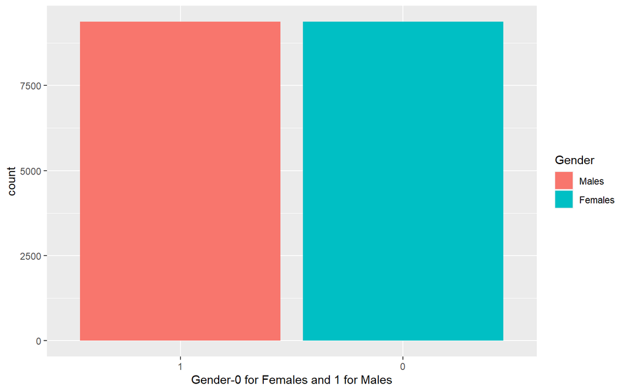

```r
library("ggplot2")

compute <- function(x) {
  freq <- table(x)
  factor(x, levels = names(sort(freq)))
}

ggplot(data, aes(x = compute(Gender))) +
  geom_bar(aes(fill = compute(Gender))) +
  xlab("Gender-0 for Females and 1 for Males")+
  scale_fill_discrete(name = "Gender", labels = c("Males", "Females"))
```

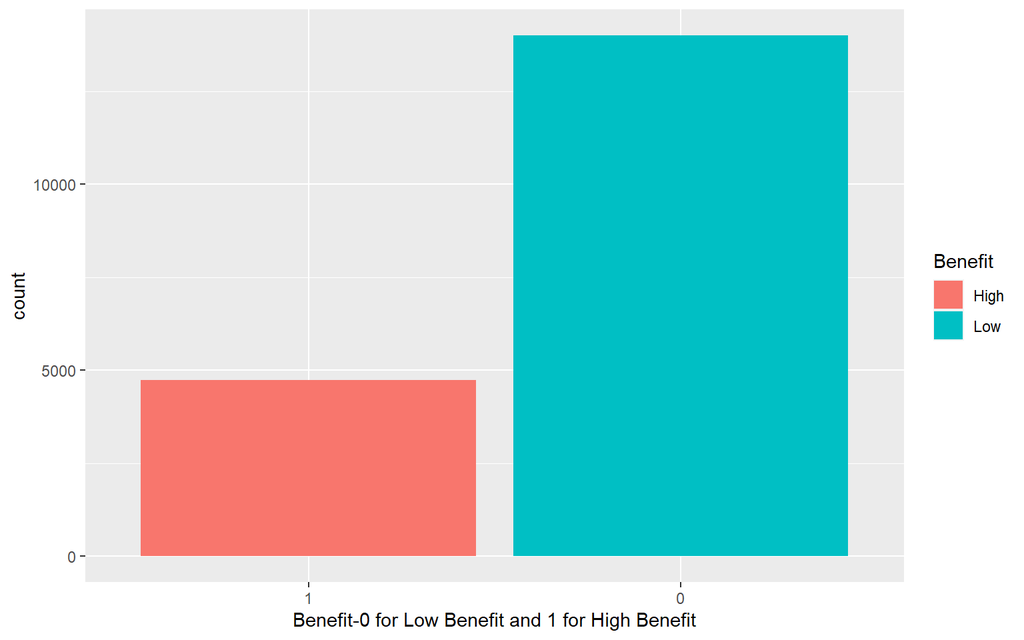

```r
ggplot(data, aes(x = compute(BH))) +
  geom_bar(aes(fill = compute(BH))) +
  xlab("Benefit-0 for Low Benefit and 1 for High Benefit")+
  scale_fill_discrete(name = "Benefit", labels = c("High", "Low"))
```

# Chapter 1

```r
############################Life table
n=range(ceiling(data$EntAge+data$TObs))
k=n[2]-n[1]+1
Ex_c=c()
dx=c()
Ex=c()
for(i in 1:k){

  newdata <- subset(data, (data$EntAge<(60+i)  &  data$EntAge>=(60+i-1)) | ( (data$EntAge+data$TObs-i+1)>0 & data$EntAge<(60+i) & data$EntAge+data$TObs>=(60+i-1)),
                    select=c(Status,TObs,EntAge))

  t=ifelse((newdata$EntAge<(60+i)  &  newdata$EntAge>=(60+i-1)),(ifelse((newdata$TObs+newdata$EntAge)>=(60+i),(60+i)-newdata$EntAge,newdata$TObs)),ifelse((newdata$TObs+newdata$EntAge-(60+i-1))>=1,1,(newdata$TObs+newdata$EntAge-(60+i-1))))
  d=sum(ifelse(newdata$Status==1  &  ((newdata$EntAge+newdata$TObs)<(60+i) & (newdata$EntAge+newdata$TObs)>=(60+i-1)),1,0))
  Ex_c[i]=sum(t)
  dx[i]=d
  Ex[i]=nrow(newdata)
}
Ex_c=round(Ex_c,4)
x=seq(60,103,by=1)
life_table=data.frame(age_interval=paste0("(",x,",",(x+1),")"),Ex_c,dx,Ex)
knitr::kable(rbind(life_table,c(paste0("All ages"),colSums(life_table[,2:4]))))
```

| age_interval | Ex_c | dx | Ex |
| --- | --- | --- | --- |
| (60,61) | 8294.4034 | 75 | 9145 |
| (61,62) | 8352.1373 | 76 | 9123 |
| (62,63) | 8347.9795 | 78 | 9178 |
| (63,64) | 8170.4034 | 67 | 9008 |
| (64,65) | 8216.2636 | 76 | 8918 |
| (65,66) | 9989.0697 | 105 | 10659 |
| (66,67) | 9687.8667 | 103 | 10336 |
| (67,68) | 9364.2423 | 136 | 9929 |
| (68,69) | 9083.8628 | 126 | 9603 |
| (69,70) | 8730.3804 | 144 | 9276 |
| (70,71) | 8376.2953 | 153 | 8888 |
| (71,72) | 7979.1936 | 178 | 8507 |
| (72,73) | 7580.3145 | 174 | 8107 |
| (73,74) | 7152.2833 | 201 | 7626 |
| (74,75) | 6591.6027 | 190 | 7023 |
| (75,76) | 6074.4258 | 209 | 6499 |
| (76,77) | 5573.1965 | 193 | 5984 |
| (77,78) | 5109.1304 | 209 | 5521 |
| (78,79) | 4610.5482 | 209 | 4967 |
| (79,80) | 4100.0293 | 216 | 4452 |
| (80,81) | 3623.8329 | 206 | 3929 |
| (81,82) | 3138.1248 | 211 | 3431 |
| (82,83) | 2711.5971 | 194 | 2964 |
| (83,84) | 2334.0033 | 190 | 2562 |
| (84,85) | 1977.8714 | 167 | 2168 |
| (85,86) | 1653.5534 | 157 | 1821 |
| (86,87) | 1357.0119 | 169 | 1520 |
| (87,88) | 1104.6109 | 122 | 1227 |
| (88,89) | 874.1044 | 130 | 995 |
| (89,90) | 665.7625 | 114 | 769 |
| (90,91) | 494.1478 | 85 | 579 |
| (91,92) | 381.2227 | 67 | 434 |
| (92,93) | 292.1854 | 59 | 335 |
| (93,94) | 206.3981 | 54 | 253 |
| (94,95) | 148.9825 | 33 | 173 |
| (95,96) | 95.6852 | 29 | 121 |
| (96,97) | 57.6627 | 22 | 73 |
| (97,98) | 37.0979 | 9 | 44 |
| (98,99) | 24.8032 | 6 | 29 |
| (99,100) | 16.9296 | 7 | 23 |
| (100,101) | 9.5345 | 4 | 13 |
| (101,102) | 6.0269 | 2 | 7 |
| (102,103) | 5 | 0 | 5 |
| (103,104) | 1.608 | 1 | 5 |
| All ages | 172601.3858 | 4956 | 186229 |

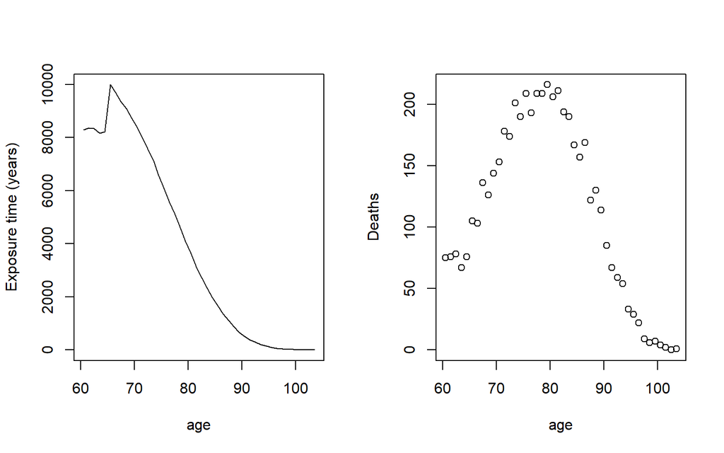

```r
mid_age=seq(60.5,103.5,by=1)
############################Figure 1.1
require(knitr)
layout(t(1:2))
plot(mid_age,life_table$Ex_c,xlab="age",ylab="Exposure time (years)",type="l")
plot(mid_age,life_table$dx,xlab="age",ylab="Deaths")
```

Figure 1.1 Exposure time (left panel) and deaths (right panel) by age.

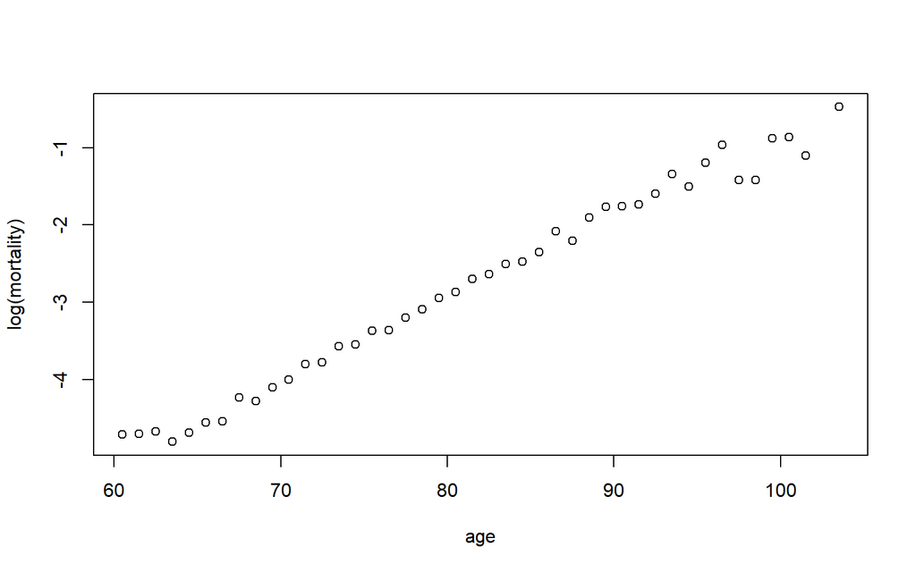

```r
############################initial rate of mortality
life_table$q_hat=life_table$dx/life_table$Ex
############################central rate of mortality-Figure 1.2
life_table$m_hat=life_table$dx/life_table$Ex_c
plot(mid_age,log(life_table$m_hat),xlab="age",ylab="log(mortality)")
```

Figure 1.2 Crude log mortality ratios, $log(m ̂_x)$, for single years of age x.

```r
knitr::kable(life_table)
```

| age_interval | Ex_c | dx | Ex | q_hat | m_hat |
| --- | --- | --- | --- | --- | --- |
| (60,61) | 8294.4034 | 75 | 9145 | 0.0082012 | 0.0090422 |
| (61,62) | 8352.1373 | 76 | 9123 | 0.0083306 | 0.0090995 |
| (62,63) | 8347.9795 | 78 | 9178 | 0.0084986 | 0.0093436 |
| (63,64) | 8170.4034 | 67 | 9008 | 0.0074378 | 0.0082003 |
| (64,65) | 8216.2636 | 76 | 8918 | 0.0085221 | 0.0092499 |
| (65,66) | 9989.0697 | 105 | 10659 | 0.0098508 | 0.0105115 |
| (66,67) | 9687.8667 | 103 | 10336 | 0.0099652 | 0.0106319 |
| (67,68) | 9364.2423 | 136 | 9929 | 0.0136973 | 0.0145233 |
| (68,69) | 9083.8628 | 126 | 9603 | 0.0131209 | 0.0138708 |
| (69,70) | 8730.3804 | 144 | 9276 | 0.0155239 | 0.0164941 |
| (70,71) | 8376.2953 | 153 | 8888 | 0.0172142 | 0.0182658 |
| (71,72) | 7979.1936 | 178 | 8507 | 0.0209239 | 0.0223080 |
| (72,73) | 7580.3145 | 174 | 8107 | 0.0214629 | 0.0229542 |
| (73,74) | 7152.2833 | 201 | 7626 | 0.0263572 | 0.0281029 |
| (74,75) | 6591.6027 | 190 | 7023 | 0.0270540 | 0.0288246 |
| (75,76) | 6074.4258 | 209 | 6499 | 0.0321588 | 0.0344065 |
| (76,77) | 5573.1965 | 193 | 5984 | 0.0322527 | 0.0346300 |
| (77,78) | 5109.1304 | 209 | 5521 | 0.0378555 | 0.0409072 |
| (78,79) | 4610.5482 | 209 | 4967 | 0.0420777 | 0.0453308 |
| (79,80) | 4100.0293 | 216 | 4452 | 0.0485175 | 0.0526826 |
| (80,81) | 3623.8329 | 206 | 3929 | 0.0524306 | 0.0568459 |
| (81,82) | 3138.1248 | 211 | 3431 | 0.0614981 | 0.0672376 |
| (82,83) | 2711.5971 | 194 | 2964 | 0.0654521 | 0.0715446 |
| (83,84) | 2334.0033 | 190 | 2562 | 0.0741608 | 0.0814052 |
| (84,85) | 1977.8714 | 167 | 2168 | 0.0770295 | 0.0844342 |
| (85,86) | 1653.5534 | 157 | 1821 | 0.0862164 | 0.0949470 |
| (86,87) | 1357.0119 | 169 | 1520 | 0.1111842 | 0.1245383 |
| (87,88) | 1104.6109 | 122 | 1227 | 0.0994295 | 0.1104461 |
| (88,89) | 874.1044 | 130 | 995 | 0.1306533 | 0.1487237 |
| (89,90) | 665.7625 | 114 | 769 | 0.1482445 | 0.1712322 |
| (90,91) | 494.1478 | 85 | 579 | 0.1468048 | 0.1720133 |
| (91,92) | 381.2227 | 67 | 434 | 0.1543779 | 0.1757503 |
| (92,93) | 292.1854 | 59 | 335 | 0.1761194 | 0.2019266 |
| (93,94) | 206.3981 | 54 | 253 | 0.2134387 | 0.2616303 |
| (94,95) | 148.9825 | 33 | 173 | 0.1907514 | 0.2215025 |
| (95,96) | 95.6852 | 29 | 121 | 0.2396694 | 0.3030772 |
| (96,97) | 57.6627 | 22 | 73 | 0.3013699 | 0.3815291 |
| (97,98) | 37.0979 | 9 | 44 | 0.2045455 | 0.2426013 |
| (98,99) | 24.8032 | 6 | 29 | 0.2068966 | 0.2419043 |
| (99,100) | 16.9296 | 7 | 23 | 0.3043478 | 0.4134770 |
| (100,101) | 9.5345 | 4 | 13 | 0.3076923 | 0.4195291 |
| (101,102) | 6.0269 | 2 | 7 | 0.2857143 | 0.3318456 |
| (102,103) | 5.0000 | 0 | 5 | 0.0000000 | 0.0000000 |
| (103,104) | 1.6080 | 1 | 5 | 0.2000000 | 0.6218905 |

Table 1.1 Mortality data ;age intervals, central exposed to risk (denoted by Ex_c ), initial exposed to risk ( denoted by Ex ), deaths ( denoted by dx ) initial rate of mortality ( denoted by q_hat ), central rate of mortality ( denoted by m_hat)

## 1.5 Fitting a Model to Grouped Counts

```r
############################GLM_Fitting a Model to the complete data
oModelOne = glm(life_table$dx ~ 1, offset=log(life_table$Ex_c),
                family=poisson)
summary(oModelOne)
```

```
##
## Call:
## glm(formula = life_table$dx ~ 1, family = poisson, offset = log(life_table$Ex_c))
##
## Deviance Residuals:
##     Min       1Q   Median       3Q      Max
## -12.934   -4.149    4.310   11.121   15.358
##
## Coefficients:
##             Estimate Std. Error z value Pr(>|z|)
## (Intercept)  -3.5504     0.0142  -249.9   <2e-16 ***
## ---
## Signif. codes:  0 '***' 0.001 '**' 0.01 '*' 0.05 '.' 0.1 ' ' 1
##
## (Dispersion parameter for poisson family taken to be 1)
##
##     Null deviance: 3954  on 43  degrees of freedom
## Residual deviance: 3954  on 43  degrees of freedom
## AIC: 4219.2
##
## Number of Fisher Scoring iterations: 5
```

```r
library("sjPlot")
tab_model(oModelOne ,  show.stat = TRUE,title="Estimates of m,
 model has fitted a single constant parameter applying across all ages",string.p="p-values")
```

Estimates of m, model has fitted a single constant parameter applying across all ages

|  | life_table$dx |  |  |  |
| --- | --- | --- | --- | --- |
| Predictors | Incidence Rate Ratios | CI | Statistic | p-values |
| (Intercept) | 0.03 | 0.03 – 0.03 | -249.94 | **<0.001** |
| Observations | 44 |  |  |  |
| R<sup>2</sup> Nagelkerke | 0.000 |  |  |  |

```r
overall_centeral_rate = exp(oModelOne$coefficients) ; overall_centeral_rate
```

```
## (Intercept)
##  0.02871356
```

```r
############################GLM_Fitting a Model to Grouped Counts
vAgeBand=as.factor(mid_age)
oModelTwo = glm(life_table$dx ~ -1 + vAgeBand,
                offset=log(life_table$Ex_c), family=poisson)
summary(oModelTwo)
```

```
##
## Call:
## glm(formula = life_table$dx ~ -1 + vAgeBand, family = poisson,
##     offset = log(life_table$Ex_c))
##
## Deviance Residuals:
##  [1]  0  0  0  0  0  0  0  0  0  0  0  0  0  0  0  0  0  0  0  0  0  0  0  0  0
## [26]  0  0  0  0  0  0  0  0  0  0  0  0  0  0  0  0  0  0  0
##
## Coefficients:
##                 Estimate Std. Error z value Pr(>|z|)
## vAgeBand60.5  -4.706e+00  1.155e-01 -40.754  < 2e-16 ***
## vAgeBand61.5  -4.700e+00  1.147e-01 -40.970  < 2e-16 ***
## vAgeBand62.5  -4.673e+00  1.132e-01 -41.271  < 2e-16 ***
## vAgeBand63.5  -4.804e+00  1.222e-01 -39.319  < 2e-16 ***
## vAgeBand64.5  -4.683e+00  1.147e-01 -40.827  < 2e-16 ***
## vAgeBand65.5  -4.555e+00  9.759e-02 -46.678  < 2e-16 ***
## vAgeBand66.5  -4.544e+00  9.853e-02 -46.116  < 2e-16 ***
## vAgeBand67.5  -4.232e+00  8.575e-02 -49.353  < 2e-16 ***
## vAgeBand68.5  -4.278e+00  8.909e-02 -48.020  < 2e-16 ***
## vAgeBand69.5  -4.105e+00  8.333e-02 -49.257  < 2e-16 ***
## vAgeBand70.5  -4.003e+00  8.085e-02 -49.511  < 2e-16 ***
## vAgeBand71.5  -3.803e+00  7.495e-02 -50.736  < 2e-16 ***
## vAgeBand72.5  -3.774e+00  7.581e-02 -49.786  < 2e-16 ***
## vAgeBand73.5  -3.572e+00  7.053e-02 -50.640  < 2e-16 ***
## vAgeBand74.5  -3.547e+00  7.255e-02 -48.886  < 2e-16 ***
## vAgeBand75.5  -3.370e+00  6.917e-02 -48.712  < 2e-16 ***
## vAgeBand76.5  -3.363e+00  7.198e-02 -46.721  < 2e-16 ***
## vAgeBand77.5  -3.196e+00  6.917e-02 -46.211  < 2e-16 ***
## vAgeBand78.5  -3.094e+00  6.917e-02 -44.726  < 2e-16 ***
## vAgeBand79.5  -2.943e+00  6.804e-02 -43.260  < 2e-16 ***
## vAgeBand80.5  -2.867e+00  6.967e-02 -41.155  < 2e-16 ***
## vAgeBand81.5  -2.700e+00  6.884e-02 -39.213  < 2e-16 ***
## vAgeBand82.5  -2.637e+00  7.180e-02 -36.735  < 2e-16 ***
## vAgeBand83.5  -2.508e+00  7.255e-02 -34.575  < 2e-16 ***
## vAgeBand84.5  -2.472e+00  7.738e-02 -31.942  < 2e-16 ***
## vAgeBand85.5  -2.354e+00  7.981e-02 -29.501  < 2e-16 ***
## vAgeBand86.5  -2.083e+00  7.692e-02 -27.081  < 2e-16 ***
## vAgeBand87.5  -2.203e+00  9.054e-02 -24.335  < 2e-16 ***
## vAgeBand88.5  -1.906e+00  8.771e-02 -21.728  < 2e-16 ***
```

[output cut: 10 more lines]

```
## vAgeBand99.5  -8.831e-01  3.780e-01  -2.337 0.019460 *
## vAgeBand100.5 -8.686e-01  5.000e-01  -1.737 0.082344 .
## vAgeBand101.5 -1.103e+00  7.071e-01  -1.560 0.118760
## vAgeBand102.5 -2.391e+01  4.225e+04  -0.001 0.999548
## vAgeBand103.5 -4.750e-01  1.000e+00  -0.475 0.634793
## ---
## Signif. codes:  0 '***' 0.001 '**' 0.01 '*' 0.05 '.' 0.1 ' ' 1
##
## (Dispersion parameter for poisson family taken to be 1)
##
##     Null deviance: 3.0405e+05  on 44  degrees of freedom
## Residual deviance: 4.1243e-10  on  0  degrees of freedom
## AIC: 351.18
##
## Number of Fisher Scoring iterations: 20
```

```r
tab_model(oModelTwo,  show.stat = TRUE ,
          title="Estimates of m for each age group, together with standard errors and p-values",string.p="p-values")
```

Estimates of m for each age group, together with standard errors and p-values

|  | life_table$dx |  |  |  |
| --- | --- | --- | --- | --- |
| Predictors | Incidence Rate Ratios | CI | Statistic | p-values |
| vAgeBand [60.5] | 0.01 | 0.01 – 0.01 | -40.75 | **<0.001** |
| vAgeBand [61.5] | 0.01 | 0.01 – 0.01 | -40.97 | **<0.001** |
| vAgeBand [62.5] | 0.01 | 0.01 – 0.01 | -41.27 | **<0.001** |
| vAgeBand [63.5] | 0.01 | 0.01 – 0.01 | -39.32 | **<0.001** |
| vAgeBand [64.5] | 0.01 | 0.01 – 0.01 | -40.83 | **<0.001** |
| vAgeBand [65.5] | 0.01 | 0.01 – 0.01 | -46.68 | **<0.001** |
| vAgeBand [66.5] | 0.01 | 0.01 – 0.01 | -46.12 | **<0.001** |
| vAgeBand [67.5] | 0.01 | 0.01 – 0.02 | -49.35 | **<0.001** |
| vAgeBand [68.5] | 0.01 | 0.01 – 0.02 | -48.02 | **<0.001** |
| vAgeBand [69.5] | 0.02 | 0.01 – 0.02 | -49.26 | **<0.001** |
| vAgeBand [70.5] | 0.02 | 0.02 – 0.02 | -49.51 | **<0.001** |
| vAgeBand [71.5] | 0.02 | 0.02 – 0.03 | -50.74 | **<0.001** |
| vAgeBand [72.5] | 0.02 | 0.02 – 0.03 | -49.79 | **<0.001** |
| vAgeBand [73.5] | 0.03 | 0.02 – 0.03 | -50.64 | **<0.001** |
| vAgeBand [74.5] | 0.03 | 0.03 – 0.03 | -48.89 | **<0.001** |
| vAgeBand [75.5] | 0.03 | 0.03 – 0.04 | -48.71 | **<0.001** |
| vAgeBand [76.5] | 0.03 | 0.03 – 0.04 | -46.72 | **<0.001** |
| vAgeBand [77.5] | 0.04 | 0.04 – 0.05 | -46.21 | **<0.001** |
| vAgeBand [78.5] | 0.05 | 0.04 – 0.05 | -44.73 | **<0.001** |
| vAgeBand [79.5] | 0.05 | 0.05 – 0.06 | -43.26 | **<0.001** |
| vAgeBand [80.5] | 0.06 | 0.05 – 0.07 | -41.16 | **<0.001** |
| vAgeBand [81.5] | 0.07 | 0.06 – 0.08 | -39.21 | **<0.001** |
| vAgeBand [82.5] | 0.07 | 0.06 – 0.08 | -36.74 | **<0.001** |
| vAgeBand [83.5] | 0.08 | 0.07 – 0.09 | -34.57 | **<0.001** |
| vAgeBand [84.5] | 0.08 | 0.07 – 0.10 | -31.94 | **<0.001** |
| vAgeBand [85.5] | 0.09 | 0.08 – 0.11 | -29.50 | **<0.001** |
| vAgeBand [86.5] | 0.12 | 0.11 – 0.14 | -27.08 | **<0.001** |
| vAgeBand [87.5] | 0.11 | 0.09 – 0.13 | -24.34 | **<0.001** |
| vAgeBand [88.5] | 0.15 | 0.13 – 0.18 | -21.73 | **<0.001** |
| vAgeBand [89.5] | 0.17 | 0.14 – 0.21 | -18.84 | **<0.001** |
| vAgeBand [90.5] | 0.17 | 0.14 – 0.21 | -16.23 | **<0.001** |
| vAgeBand [91.5] | 0.18 | 0.14 – 0.22 | -14.23 | **<0.001** |
| vAgeBand [92.5] | 0.20 | 0.16 – 0.26 | -12.29 | **<0.001** |
| vAgeBand [93.5] | 0.26 | 0.20 – 0.34 | -9.85 | **<0.001** |
| vAgeBand [94.5] | 0.22 | 0.16 – 0.31 | -8.66 | **<0.001** |
| vAgeBand [95.5] | 0.30 | 0.21 – 0.44 | -6.43 | **<0.001** |
| vAgeBand [96.5] | 0.38 | 0.25 – 0.58 | -4.52 | **<0.001** |
| vAgeBand [97.5] | 0.24 | 0.13 – 0.47 | -4.25 | **<0.001** |
| vAgeBand [98.5] | 0.24 | 0.11 – 0.54 | -3.48 | **0.001** |
| vAgeBand [99.5] | 0.41 | 0.20 – 0.87 | -2.34 | **0.019** |
| vAgeBand [100.5] | 0.42 | 0.16 – 1.12 | -1.74 | 0.082 |
| vAgeBand [101.5] | 0.33 | 0.08 – 1.33 | -1.56 | 0.119 |
| vAgeBand [102.5] | 0.00 | 0.00 – Inf | -0.00 | 1.000 |
| vAgeBand [103.5] | 0.62 | 0.09 – 4.41 | -0.47 | 0.635 |
| Observations | 44 |  |  |  |
| R<sup>2</sup> Nagelkerke | 1.000 |  |  |  |

```r
centeral_rate = data.frame(centeral_rate = exp(oModelTwo$coefficients) , m_hat = life_table$m_hat)
knitr::kable(centeral_rate)
```

|  | centeral_rate | m_hat |
| --- | --- | --- |
| vAgeBand60.5 | 0.0090422 | 0.0090422 |
| vAgeBand61.5 | 0.0090995 | 0.0090995 |
| vAgeBand62.5 | 0.0093436 | 0.0093436 |
| vAgeBand63.5 | 0.0082003 | 0.0082003 |
| vAgeBand64.5 | 0.0092499 | 0.0092499 |
| vAgeBand65.5 | 0.0105115 | 0.0105115 |
| vAgeBand66.5 | 0.0106319 | 0.0106319 |
| vAgeBand67.5 | 0.0145233 | 0.0145233 |
| vAgeBand68.5 | 0.0138708 | 0.0138708 |
| vAgeBand69.5 | 0.0164941 | 0.0164941 |
| vAgeBand70.5 | 0.0182658 | 0.0182658 |
| vAgeBand71.5 | 0.0223080 | 0.0223080 |
| vAgeBand72.5 | 0.0229542 | 0.0229542 |
| vAgeBand73.5 | 0.0281029 | 0.0281029 |
| vAgeBand74.5 | 0.0288246 | 0.0288246 |
| vAgeBand75.5 | 0.0344065 | 0.0344065 |
| vAgeBand76.5 | 0.0346300 | 0.0346300 |
| vAgeBand77.5 | 0.0409072 | 0.0409072 |
| vAgeBand78.5 | 0.0453308 | 0.0453308 |
| vAgeBand79.5 | 0.0526826 | 0.0526826 |
| vAgeBand80.5 | 0.0568459 | 0.0568459 |
| vAgeBand81.5 | 0.0672376 | 0.0672376 |
| vAgeBand82.5 | 0.0715446 | 0.0715446 |
| vAgeBand83.5 | 0.0814052 | 0.0814052 |
| vAgeBand84.5 | 0.0844342 | 0.0844342 |
| vAgeBand85.5 | 0.0949470 | 0.0949470 |
| vAgeBand86.5 | 0.1245383 | 0.1245383 |
| vAgeBand87.5 | 0.1104461 | 0.1104461 |
| vAgeBand88.5 | 0.1487237 | 0.1487237 |
| vAgeBand89.5 | 0.1712322 | 0.1712322 |
| vAgeBand90.5 | 0.1720133 | 0.1720133 |
| vAgeBand91.5 | 0.1757503 | 0.1757503 |
| vAgeBand92.5 | 0.2019266 | 0.2019266 |
| vAgeBand93.5 | 0.2616303 | 0.2616303 |
| vAgeBand94.5 | 0.2215025 | 0.2215025 |
| vAgeBand95.5 | 0.3030772 | 0.3030772 |
| vAgeBand96.5 | 0.3815291 | 0.3815291 |
| vAgeBand97.5 | 0.2426013 | 0.2426013 |
| vAgeBand98.5 | 0.2419043 | 0.2419043 |
| vAgeBand99.5 | 0.4134770 | 0.4134770 |
| vAgeBand100.5 | 0.4195291 | 0.4195291 |
| vAgeBand101.5 | 0.3318456 | 0.3318456 |
| vAgeBand102.5 | 0.0000000 | 0.0000000 |
| vAgeBand103.5 | 0.6218905 | 0.6218905 |

# Chapter 5

## 5.5 Fitting the Gompertz Model

```r
############################5.5 Fitting the GompertzTObsTObs Model
FullNegLogL=function(p,data){

  a=p[1]
  b=p[2]
  x=data$EntAge
  d=data$Status
  t=data$TObs

  sum(((exp(b*t)-1)/b)*exp(a+(b*x)))-sum(d*(a+(b*(x+t))))
}

Estimates = nlm(FullNegLogL , p = c(-10 , 0.1),data , typsize = c(-11 , 0.09) , gradtol = 1e-10 , hessian = T) ;Estimates
```

```
## $minimum
## [1] 20592.61
##
## $estimate
## [1] -11.5830742   0.1083304
##
## $gradient
## [1] -4.711157e-09 -5.037339e-07
##
## $hessian
##            [,1]       [,2]
## [1,]   4961.454   385948.1
## [2,] 385948.090 30379523.1
##
## $code
## [1] 1
##
## $iterations
## [1] 16
```

Figure 5.1 Output from fitting Gompertz model to data .

### Checking model identifiability

```r
############################Hessian
eigen(Estimates$hessian)$value
```

```
## [1] 3.038443e+07 5.827584e+01
```

```r
Identifiability = function(Estimates , gradtol = 10^length(Estimates$estimate)){
  if(sum(sign(eigen(Estimates$hessian)$value))/length(eigen(Estimates$hessian)$value) ==(-1) & sum(eigen(Estimates$hessian)$value)<gradtol){
    cat('The model is Identifiable')
  }
  else{cat('The model is not Identifiable')}
}
Identifiability(Estimates)
```

```
## The model is not Identifiable
```

# Chapter 6

## Information Criteria

### 6.4.1 Akaike’s Information Criterion and 6.4.2 The Bayesian Information Criterion

```r
############################Akaike’s Information Criterion
AIC_funct =function(data,p){
  k=length(p)
  return((-2)*(-FullNegLogL(p,data))+2*k)
}
AIC_c_funct=function(data,p){
  k=length(p)
  n=nrow(data)
  return(AIC_funct(data,p)+(2*k*(k+1)/(n-k-1)))
}
p=Estimates$estimate
AIC =AIC_funct(data,p)
AIC_c=AIC_c_funct(data,p)

############################The Bayesian Information Criterion
BIC_funct =function(data,p){
  k=length(p)
  n=nrow(data)
  return((-2)*(-FullNegLogL(p,data))+k*log(n))
}
BIC =BIC_funct(data,p)
knitr::kable(data.frame(AIC =AIC ,AIC_c=AIC_c,BIC=BIC))
```

| AIC | AIC_c | BIC |
| --- | --- | --- |
| 41189.23 | 41189.23 | 41204.9 |

### Poisson deviance residual (6.14)

```r
############################Poisson deviance residual_rj
rj_Calc = function(data){

  Estimates = nlm(FullNegLogL , p = c(-10 , 0.1),data , typsize = c(-10 , 0.1) , gradtol = 1e-10)
  a=Estimates$estimate[1]
  b=Estimates$estimate[2]

  #######################################
  n=range(ceiling(data$EntAge+data$TObs))
  k=n[2]-n[1]+1
  w=c()
  landa=c()
  rj=c()
  s=0
  t2=0
  for(i in 1:k){

    newdata <- subset(data, (data$EntAge<(60+i)  &  data$EntAge>=(60+i-1)) | ( (data$EntAge+data$TObs-i+1)>0 & data$EntAge<(60+i) & data$EntAge+data$TObs>=(60+i-1)),
                      select=c(Status,TObs,EntAge))
    w[i]=nrow(newdata)


    t=ifelse((newdata$EntAge<(60+i)  &  newdata$EntAge>=(60+i-1)),(ifelse((newdata$TObs+newdata$EntAge)>=(60+i),(60+i)-newdata$EntAge,newdata$TObs)),ifelse((newdata$TObs+newdata$EntAge-(60+i-1))>=1,1,(newdata$TObs+newdata$EntAge-(60+i-1))))
    t2=t2+sum(t)
    x=ifelse((newdata$EntAge<(60+i)  &  newdata$EntAge>=(60+i-1)),newdata$EntAge,(60+i-1))

    l=(exp(b*t)-1)*exp(a+b*x)/b
    landa[i]=sum(l)

    d=sum(ifelse(newdata$Status==1  &  ((newdata$EntAge+newdata$TObs)<(60+i) & (newdata$EntAge+newdata$TObs)>=(60+i-1)),1,0))
    s=s+d

    rj[i] = sign(d - landa[i])*sqrt(2*(d*log(d/landa[i])-(d-landa[i])))

  }
  list( landa = landa , rj = rj , totaldeath = s , totaltimelived = t2 )
}
results=rj_Calc(data)
results
```

```
## $landa
##  [1]  54.322243  60.948127  67.879222  74.033717  82.985966 112.398291
##  [7] 121.474616 130.856482 141.458428 151.493692 161.977663 171.941660
## [13] 182.031950 191.373709 196.531166 201.834752 206.380754 210.803303
## [19] 211.976634 210.045538 206.879018 199.598293 192.238821 184.351881
## [25] 174.094351 162.187128 148.280172 134.507704 118.565028 100.620144
## [31]  83.229389  71.572805  61.117864  48.065427  38.682985  27.651959
## [37]  18.566506  13.323822   9.937118   7.541799   4.733211   3.337496
## [43]   3.097875   1.070181
##
## $rj
##  [1]  2.65096898  1.85585743  1.19964336 -0.83095202 -0.77802980 -0.70570647
##  [7] -1.72165849  0.44673920 -1.32454333 -0.61395930 -0.71207188  0.45934831
## [13] -0.59977597  0.69013886 -0.46849780  0.50141062 -0.94176783 -0.12438008
## [19] -0.20492865  0.40893378 -0.06115721  0.79952722  0.12682999  0.41388980
## [25] -0.54139078 -0.40950466  1.66406545 -1.09585709  1.03392700  1.30582141
## [31]  0.19339970 -0.54643060 -0.27249065  0.83923260 -0.93759245  0.25431230
## [37]  0.77399925 -1.25925479 -1.34908310 -0.19972380 -0.34633276 -0.79164234
## [43]         NaN -0.06860357
##
## $totaldeath
## [1] 4956
##
## $totaltimelived
## [1] 172601.4
```

```r
rj=results$rj

#library("tidyr")
#rj = replace_na(rj, 0)
```

## 6.6 Statistical Tests of Fit

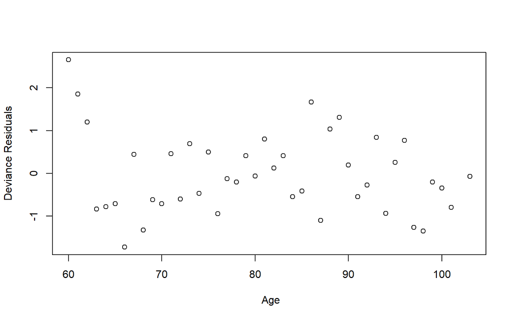

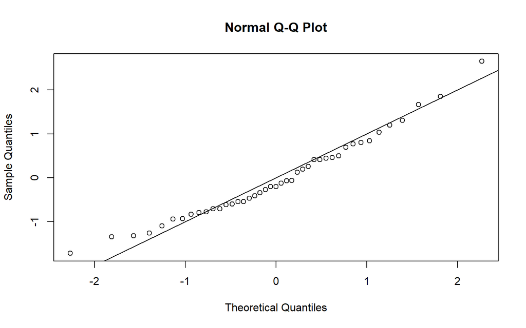

```r
############################6.6 Statistical Tests of Fit
# visualization

plotting = function(rj,data){
  Age = min(data$EntAge):(min(data$EntAge)+length(rj)-1)
  plot(Age , rj , ylab = 'Deviance Residuals' , xlab = ' Age' )
  qqnorm(rj)
  abline(0,1)
}
plotting(rj,data)
```

### 6.6.1 The $χ^2$ Test

```r
### 6.6.1 The χ2 Test
# chisquare test

chisquaretest = function(rj , alpha = 0.05){
  rj = na.omit(rj)
  test_statistics = sum(rj^2)
  if( pchisq(test_statistics, length(rj) , lower.tail = F)>alpha){cat('Null hypothesis has been accepted with a p_value of' , pchisq(test_statistics, length(rj) , lower.tail = F) , ' with a test statistic of' , test_statistics)}
  else{cat('Null hypothesis has been rejected with a p_value of' , pchisq(test_statistics, length(rj) , lower.tail = F), ' with a test statistic of' , test_statistics)}

}
chisquaretest(rj)
```

```
## Null hypothesis has been accepted with a p_value of 0.7270279  with a test statistic of 37.02619
```

### 6.6.2 The Standardised-Deviations Test

```r
# standardized chisquare test way 1
library(DescTools)
chisquarestandardizedtest_1 = function(rj , alpha = 0.05){
  rj = na.omit(rj)
  n=sum(complete.cases(rj))
  m=floor(n^0.5)
  test=PearsonTest(rj,n.classes=(m),adjust = FALSE)
  if( (test$p)>alpha){cat('Null hypothesis has been accepted with a p_value of' , test$p , ' with a test statistic of' , test$statistic)}
  else{cat('Null hypothesis has been rejected with a p_value of' , test$p , ' with a test statistic of' , test$statistic)}
}
chisquarestandardizedtest_1(rj)
```

```
## Null hypothesis has been accepted with a p_value of 0.3669537  with a test statistic of 5.418605
```

```r
# standardized chisquare test way 2
chisquarestandardizedtest_2 = function(rj , include.mean_sd = c('TRUE' , 'FALSE'), alpha = 0.05){
  library(DescTools)
  rj = na.omit(rj)
  m = floor(sqrt(length(rj)))
  i=c(2:m-1)
  if(include.mean_sd=='TRUE'){
    breaks=qnorm(i/m , mean(rj) , sd(rj))
    breaks=append(breaks,(max(rj)+1))
    breaks=append(breaks,(min(rj)-1),0)
  }
  if(include.mean_sd=='FALSE'){
    breaks=qnorm(i/m)
    breaks=append(breaks,(max(rj)+1))
    breaks=append(breaks,(min(rj)-1),0)
  }
  table = cbind(Freq(rj ,breaks)[,c(1,2)] , f = length(rj)/m , expression = (Freq(rj ,breaks)$freq - length(rj)/m)^2/(length(rj)/m))
  test_statistics = sum(table$expression)
  if( pchisq(test_statistics, (m-1) , lower.tail = F)>alpha){cat('Null hypothesis has been accepted with a p_value of' , pchisq(test_statistics, (m-1) , lower.tail = F) , ' with a test statistic of' , test_statistics)}
  else{cat('Null hypothesis has been rejected with a p_value of' , pchisq(test_statistics, (m-1) , lower.tail = F), ' with a test statistic of' , test_statistics)}
  return(table)
}
table_chisq_pearson=chisquarestandardizedtest_2(rj , include.mean_sd = TRUE)
```

```
## Null hypothesis has been accepted with a p_value of 0.3669537  with a test statistic of 5.418605
```

```r
knitr::kable(table_chisq_pearson)
```

| level | freq | f | expression |
| --- | --- | --- | --- |
| [-2.72,-0.938] | 6 | 7.166667 | 0.1899225 |
| (-0.938,-0.434] | 11 | 7.166667 | 2.0503876 |
| (-0.434,-0.0299] | 8 | 7.166667 | 0.0968992 |
| (-0.0299,0.374] | 3 | 7.166667 | 2.4224806 |
| (0.374,0.878] | 9 | 7.166667 | 0.4689922 |
| (0.878,3.65] | 6 | 7.166667 | 0.1899225 |

```r
table_chisq=chisquarestandardizedtest_2(rj , include.mean_sd = F)
```

```
## Null hypothesis has been accepted with a p_value of 0.4331456  with a test statistic of 4.860465
```

```r
knitr::kable(table_chisq)
```

| level | freq | f | expression |
| --- | --- | --- | --- |
| [-2.72,-0.967] | 5 | 7.166667 | 0.6550388 |
| (-0.967,-0.431] | 12 | 7.166667 | 3.2596899 |
| (-0.431,0] | 8 | 7.166667 | 0.0968992 |
| (0,0.431] | 5 | 7.166667 | 0.6550388 |
| (0.431,0.967] | 7 | 7.166667 | 0.0038760 |
| (0.967,3.65] | 6 | 7.166667 | 0.1899225 |

Table 6.3 Standardised-deviations test for residuals.

### 6.6.3 The Bias Test

```r
# Bias Test
# way 1
library(BSDA)
SIGN.test(rj , alternative = 'less' )
```

```
##
##  One-sample Sign-Test
##
## data:  rj
## s = 18, p-value = 0.1802
## alternative hypothesis: true median is less than 0
## 95 percent confidence interval:
##       -Inf 0.2199583
## sample estimates:
## median of x
##  -0.1997238
##
## Achieved and Interpolated Confidence Intervals:
##
##                   Conf.Level L.E.pt U.E.pt
## Lower Achieved CI     0.9369   -Inf 0.1934
## Interpolated CI       0.9500   -Inf 0.2200
## Upper Achieved CI     0.9670   -Inf 0.2543
```

```r
# way 2
BiasTest = function(rj , alpha = 0.05){
  rj = na.omit(rj)
  test_statistics = length(which(rj>0))
  if( pbinom(test_statistics , length(rj) , 1/2)>alpha){cat('Null hypothesis has been accepted with a p_value of' ,pbinom(test_statistics , length(rj) , 1/2) , ' with a test statistic of' , test_statistics)}
  else{cat('Null hypothesis has been rejected with a p_value of' ,pbinom(test_statistics , length(rj) , 1/2), ' with a test statistic of' , test_statistics)}
}
BiasTest(rj)
```

```
## Null hypothesis has been accepted with a p_value of 0.1801888  with a test statistic of 18
```

```r
# way 3
biastest = function(rj , alpha = 0.05){
  rj = na.omit(rj)
  test_statistics = length(which(rj>0))
  return(binom.test(test_statistics , length(rj) , 1/2 , alternative = 'less',conf.level =(1-alpha)))
}
biastest(rj)
```

```
##
##  Exact binomial test
##
## data:  test_statistics and length(rj)
## number of successes = 18, number of trials = 43, p-value = 0.1802
## alternative hypothesis: true probability of success is less than 0.5
## 95 percent confidence interval:
##  0.000000 0.555204
## sample estimates:
## probability of success
##              0.4186047
```

### 6.6.4 The Runs Test

```r
# runs test
# way 1
library(DescTools)
RunsTest(na.omit(rj))
```

```
##
##  Runs Test for Randomness
##
## data:  na.omit(rj)
## z = 0.0035915, runs = 23, m = 22, n = 21, p-value = 0.9971
## alternative hypothesis: true number of runs is not equal the expected number
## sample estimates:
##  median(x)
## -0.1997238
```

```r
#
# way 2
#library("snpar")
#runs.test(na.omit(rj))

# way 3 q=number of runs?
library("randtests")
KS_RunsTest = function(rj , alpha = 0.05){
  n = length(rj)
  rj = na.omit(rj)
  num_success = length(rle(sign(as.numeric(rj)))[[1]]) - 1
  if( pruns(q=num_success, n1=num_success, n2=(n-num_success), lower.tail =FALSE, log.p = FALSE)>alpha){cat('Null hypothesis has been accepted with a p_value of' ,pruns(q=num_success,
                                                                                                                                                                         n1=num_success, n2=(n-num_success), lower.tail =FALSE, log.p = FALSE) , ' with a test statistic of' , num_success)}
  else{cat('Null hypothesis has been rejected with a p_value of' ,pruns(q=num_success, n1=num_success, n2=(n-num_success), lower.tail =FALSE, log.p = FALSE), ' with a test statistic of' , num_success)}
}
KS_RunsTest(rj)
```

```
## Null hypothesis has been accepted with a p_value of 0.6726877  with a test statistic of 21
```

### 6.6.5 The lag-1 Autocorrelation Test

```r
# lag-1 autocorrelation test
# way 1
library(tseries)
Box.test(rj)
```

```
##
##  Box-Pierce test
##
## data:  rj
## X-squared = 0.73854, df = 1, p-value = 0.3901
```

```r
# way 2
library(EnvStats)
serialCorrelationTest(as.vector(na.omit(rj)))
```

```
## $statistic
##      RVN
## 1.928571
##
## $parameters
## NULL
##
## $p.value
## [1] 0.8148079
##
## $estimate
##       rho
## 0.1288029
##
## $estimation.method
## [1] "Yule-Walker"
##
## $null.value
## rho
##   0
##
## $alternative
## [1] "two.sided"
##
## $method
## [1] "Rank von Neumann Test for\n                                 Lag-1 Autocorrelation\n                                 (Beta Approximation)"
##
## $sample.size
## [1] 43
##
## $data.name
## [1] "as.vector(na.omit(rj))"
##
## $bad.obs
## [1] 0
##
## $interval
## $name
## [1] "Confidence"
##
## $parameter
## [1] "rho"
##
## $limits
##        LCL        UCL
## -0.1675991  0.4252049
##
## $type
## [1] "two-sided"
##
## $method
## [1] "Normal Approximation"
##
## $conf.level
## [1] 0.95
##
## attr(,"class")
## [1] "intervalEstimate"
##
## attr(,"class")
## [1] "htestEnvStats"
```

```r
# way 3 global function
lag_1_test = function(rj, alpha = 0.05){
  rj = na.omit(rj)
  n = length(rj)
  c = cor(rj[-1],rj[-n])
  Z = c*sqrt(n-1)
  if(pnorm(Z)>alpha){cat('Null hypothesis has been accepted with a p_value of' , pnorm(Z), ' with a test statistic of' , Z)}
  else{cat('Null hypothesis has been rejected with a p_value of' , pnorm(Z) , ' with a test statistic of' , Z)}
  return(data.frame(z1=sum(rj[-n])/(n-1),z2=sum(rj[-1])/(n-1),c1=c,Z=Z))
}
table_lag=lag_1_test(rj)
```

```
## Null hypothesis has been accepted with a p_value of 0.8246291  with a test statistic of 0.9331515
```

```r
knitr::kable(table_lag)
```

| z1 | z2 | c1 | Z |
| --- | --- | --- | --- |
| -0.0290163 | -0.0937681 | 0.1439884 | 0.9331515 |

(6.22-25)

### Normality test

```r
#normality test for rj
shapiro.test(rj)
```

```
##
##  Shapiro-Wilk normality test
##
## data:  rj
## W = 0.96936, p-value = 0.3004
```

```r
library("dgof")
ks.test(rj, "pnorm")
```

```
##
##  One-sample Kolmogorov-Smirnov test
##
## data:  rj
## D = 0.10578, p-value = 0.6824
## alternative hypothesis: two-sided
```

# Chapter 7

## 7.2.1 Stratifying by Gender

```r
############################Stratifying by Gender
Estimates = nlm(FullNegLogL , p = c(-10 , 0.1),data, typsize = c(-11 , 0.09) , gradtol = 1e-10)

Males<- subset(data,Gender==1,select=c(Status,TObs,EntAge,Gender))
Estimates_Males = nlm(FullNegLogL , p = c(-10 , 0.1),Males , typsize = c(-10 , 0.1) , gradtol = 1e-10 , hessian = T)
eigen(Estimates_Males$hessian)$value
```

```
## [1] 1.527759e+07 2.882436e+01
```

```r
Identifiability(Estimates_Males)
```

```
## The model is not Identifiable
```

```r
Females <- subset(data,Gender==0,select=c(Status,TObs,EntAge,Gender))
Estimates_Females= nlm(FullNegLogL , p = c(-10.5 , 0.1), Females , typsize = c(-10 , 0.1) , gradtol = 1e-10 , hessian = T)
eigen(Estimates_Females$hessian)$value
```

```
## [1] 1.510678e+07 2.942083e+01
```

```r
Identifiability(Estimates_Females)
```

```
## The model is not Identifiable
```

```r
Estimates
```

```
## $minimum
## [1] 20592.61
##
## $estimate
## [1] -11.5830742   0.1083304
##
## $gradient
## [1] -4.711157e-09 -5.037339e-07
##
## $code
## [1] 1
##
## $iterations
## [1] 16
```

```r
knitr::kable(data.frame(AIC =AIC_funct(data,Estimates$estimate)))
```

| AIC |
| --- |
| 41189.23 |

Figure 5.1 Output from fitting Gompertz model to data.

```r
Estimates_Males
```

```
## $minimum
## [1] 10269.59
##
## $estimate
## [1] -11.7738651   0.1108224
##
## $gradient
## [1] 1.544938e-09 2.462033e-07
##
## $hessian
##            [,1]       [,2]
## [1,]   2485.484   193715.6
## [2,] 193715.605 15275135.2
##
## $code
## [1] 1
##
## $iterations
## [1] 12
```

```r
knitr::kable(data.frame(AIC =AIC_funct(Males,Estimates_Males$estimate)))
```

| AIC |
| --- |
| 20543.17 |

Figure 7.3 Output from fitting Gompertz model to data, males only.

```r
Estimates_Females
```

```
## $minimum
## [1] 10321.91
##
## $estimate
## [1] -11.3956947   0.1058786
##
## $gradient
## [1] 2.394311e-09 3.435990e-07
##
## $hessian
##            [,1]       [,2]
## [1,]   2475.474   192213.2
## [2,] 192213.236 15104333.0
##
## $code
## [1] 1
##
## $iterations
## [1] 17
```

```r
knitr::kable(data.frame(AIC =AIC_funct(Females,Estimates_Females$estimate)))
```

| AIC |
| --- |
| 20647.83 |

Figure 7.5 Output from fitting Gompertz model to data, females only.

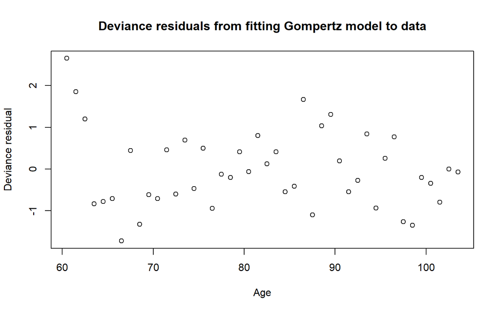

```r
rj_0=rj_Calc (data)$rj
rj_Males=rj_Calc (Males)$rj
rj_Females=rj_Calc(Females)$rj

##########
n=range(ceiling(data$EntAge+data$TObs))
k=n[2]-n[1]

x=c(floor(min(data$EntAge)):(floor(min(data$EntAge))+k))
x=x+0.5
##########final outcomes

df=cbind(x,rj_0)
df1=cbind(x,rj_Males)
df2=cbind(x,rj_Females)


df[is.na(df)] = 0
df1[is.na(df1)] = 0
df2[is.na(df2)] = 0


plot(df,xlab="Age",ylab="Deviance residual",main="Deviance residuals from fitting Gompertz model to data")
```

Figure 6.1 Deviance residuals by age calculated using equation (6.14) and the model fit from Figure 5.1.

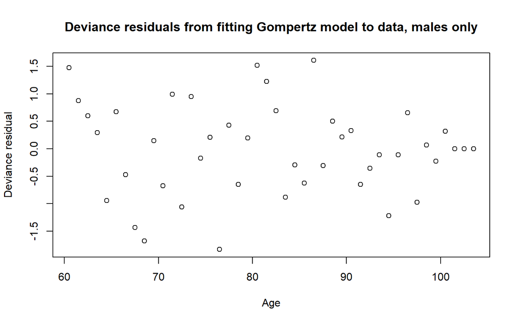

```r
plot(df1,xlab="Age",ylab="Deviance residual",main="Deviance residuals from fitting Gompertz model to data, males only")
```

Figure 7.4 Deviance residuals from fitting Gompertz model to data, males only.

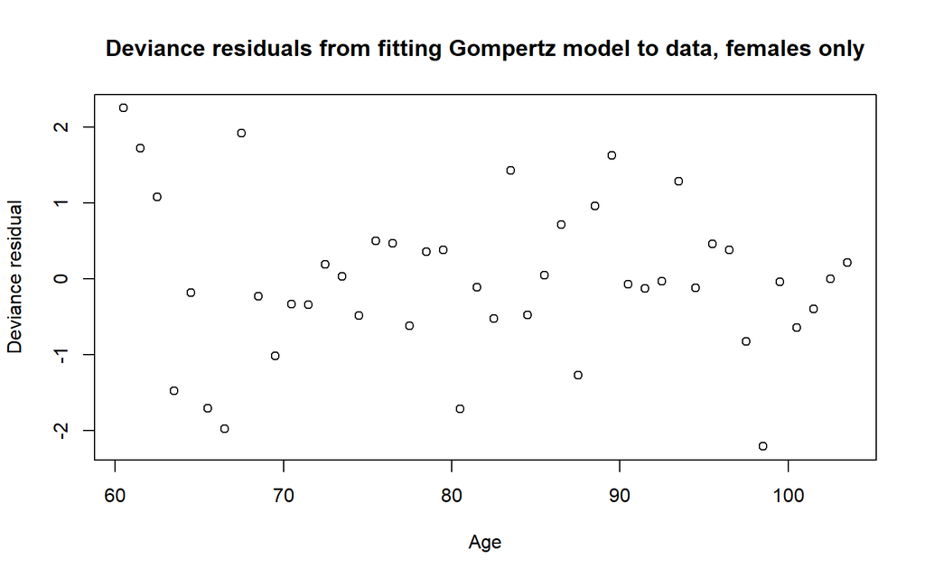

```r
plot(df2,xlab="Age",ylab="Deviance residual",main="Deviance residuals from fitting Gompertz model to data, females only")
```

Figure 7.6 Deviance residuals from fitting Gompertz model to data, females only.

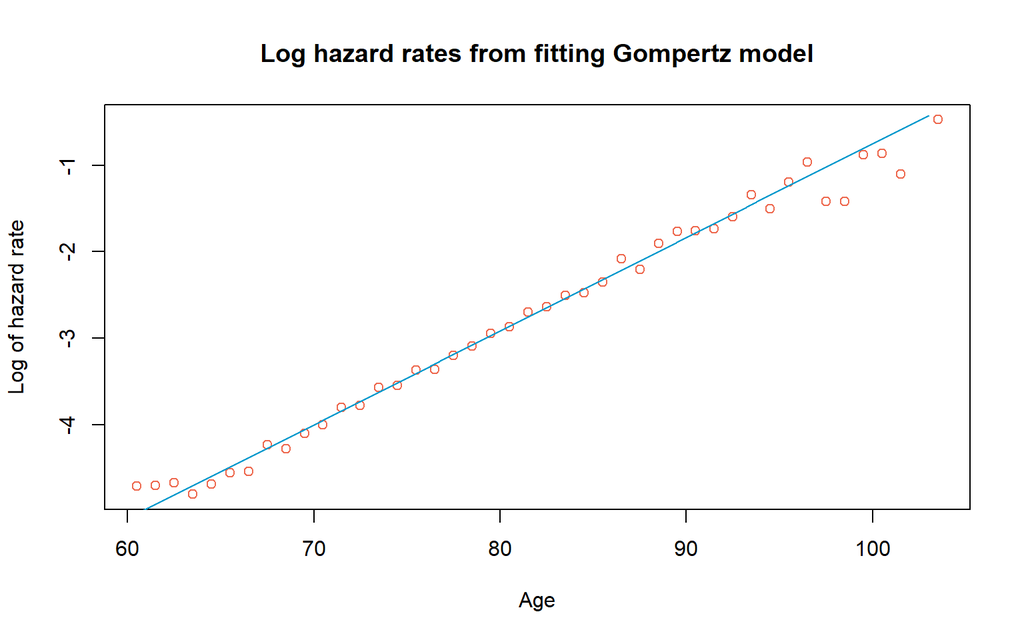

```r
Gompertz_hazard= function(x,a,b){exp(a+b*x)}
x=c(60:104)

a=Estimates$estimate[1]
b=Estimates$estimate[2]
a1=Estimates_Males$estimate[1]
b1=Estimates_Males$estimate[2]
a2=Estimates_Females$estimate[1]
b2=Estimates_Females$estimate[2]


x=c(min(data$EntAge):max(data$EntAge+data$TObs))
y=log(Gompertz_hazard(x,a=a,b=b))
plot(mid_age,log(life_table$m_hat), type = "p",
     main = "Log hazard rates from fitting Gompertz model",
     xlab="Age", ylab="Log of hazard rate",
     col = "coral2")
lines(x, y , col ="deepskyblue3" )
```

Figure 5.3 Logarithm of the crude mortality hazards for single years of age, for the Case Study, males and females combined with the Gompertz models fitted in this chapter superimposed.

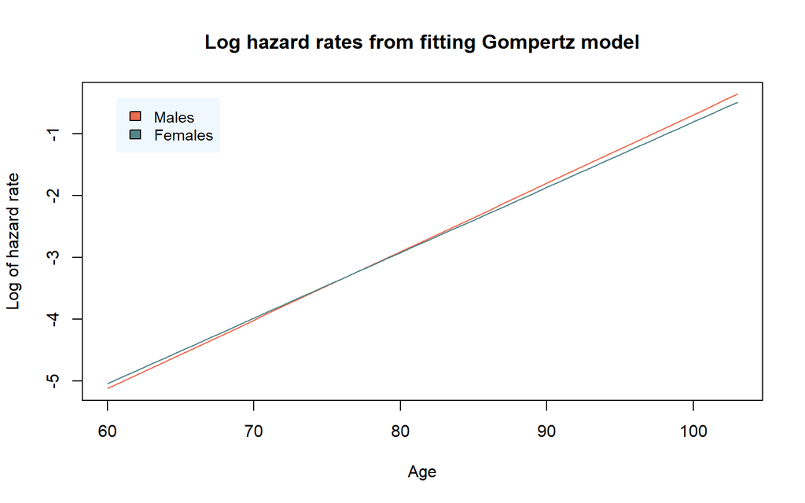

```r
x1=c(min(Males$EntAge):max(Males$EntAge+Males$TObs))
y1=log(Gompertz_hazard(x,a=a1,b=b1))

x2=c(min(Females$EntAge):max(Females$EntAge+Females$TObs))
y2=log(Gompertz_hazard(x,a=a2,b=b2))

plot(x1, y1, type = "l",
     main = "Log hazard rates from fitting Gompertz model",
     xlab="Age", ylab="Log of hazard rate",
     col = "coral2")

lines(x2, y2, col = "cadetblue4")

legend("topleft", c("Males", "Females"), fill = c("coral2", "cadetblue4"), bg="aliceblue",box.lty=0, cex=0.9,inset=0.05)
```

Figure 7.7 Log hazard rates from fitting Gompertz model to data, separately to males and females.

### 7.2.2 Stratifying by Benefit Amount

```r
############################Stratifying by Benefit Amount


low_benefit <- subset(data,BL==1,select=c(Status,TObs,EntAge,Gender))
Estimates_LB = nlm(FullNegLogL , p = c(-10.5, 0.10),low_benefit , typsize = c(-8 , 0.05) , gradtol = 1e-10 , hessian = T)
Identifiability((Estimates_LB))
```

```
## The model is not Identifiable
```

```r
high_benefit <- subset(data ,BH==1 ,select=c(Status,TObs,EntAge,Gender))
Estimates_HB = nlm(FullNegLogL , p = c(-11.5 , 0.11),high_benefit , typsize = c(-9 , 0.11) , gradtol = 1e-10 , hessian = T)
Identifiability(Estimates_HB)
```

```
## The model is not Identifiable
```

```r
Estimates_LB
```

```
## $minimum
## [1] 16546.72
##
## $estimate
## [1] -11.2751118   0.1051209
##
## $gradient
## [1] -5.162491e-08 -4.325946e-06
##
## $hessian
##            [,1]       [,2]
## [1,]   4012.208   310982.2
## [2,] 310982.242 24381955.4
##
## $code
## [1] 1
##
## $iterations
## [1] 15
```

```r
knitr::kable(data.frame(AIC =AIC_funct(low_benefit,Estimates_LB$estimate)))
```

| AIC |
| --- |
| 33097.45 |

Figure 7.8 Output from fitting Gompertz model to data , smaller pensions only.

```r
Estimates_HB
```

```
## $minimum
## [1] 4007.649
##
## $estimate
## [1] -12.7965875   0.1210251
##
## $gradient
## [1] 3.553661e-10 0.000000e+00
##
## $hessian
##            [,1]       [,2]
## [1,]   947.8525   74911.58
## [2,] 74911.5813 5995998.50
##
## $code
## [1] 1
##
## $iterations
## [1] 15
```

```r
knitr::kable(data.frame(AIC =AIC_funct(high_benefit,Estimates_HB$estimate)))
```

| AIC |
| --- |
| 8019.298 |

Figure 7.10 Output from fitting Gompertz model to data , larger pensions only.

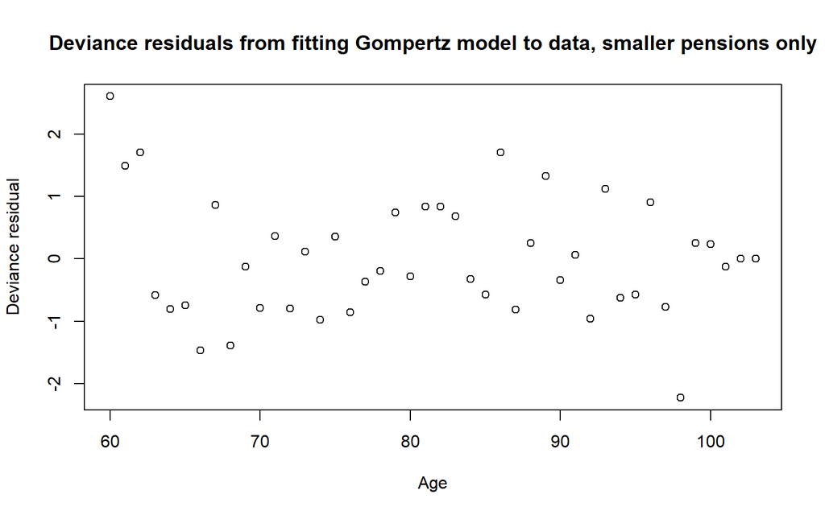

```r
rj_LB = rj_Calc(low_benefit)$rj
rj_HB= rj_Calc(high_benefit)$rj

df=cbind(x,rj_0)
df1=cbind(x,rj_LB)
df2=cbind(x,rj_HB)


df[is.na(df)] = 0
df1[is.na(df1)] = 0
df2[is.na(df2)] = 0



plot(df1,xlab="Age",ylab="Deviance residual",main="Deviance residuals from fitting Gompertz model to data, smaller pensions only")
```

Figure 7.9 Deviance residuals from fitting Gompertz model to data, smaller pensions only.

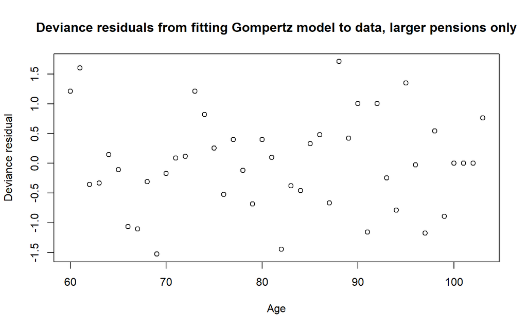

```r
plot(df2,xlab="Age",ylab="Deviance residual",main="Deviance residuals from fitting Gompertz model to data, larger pensions only")
```

Figure 7.11 Deviance residuals from fitting Gompertz model to data, larger pensions only

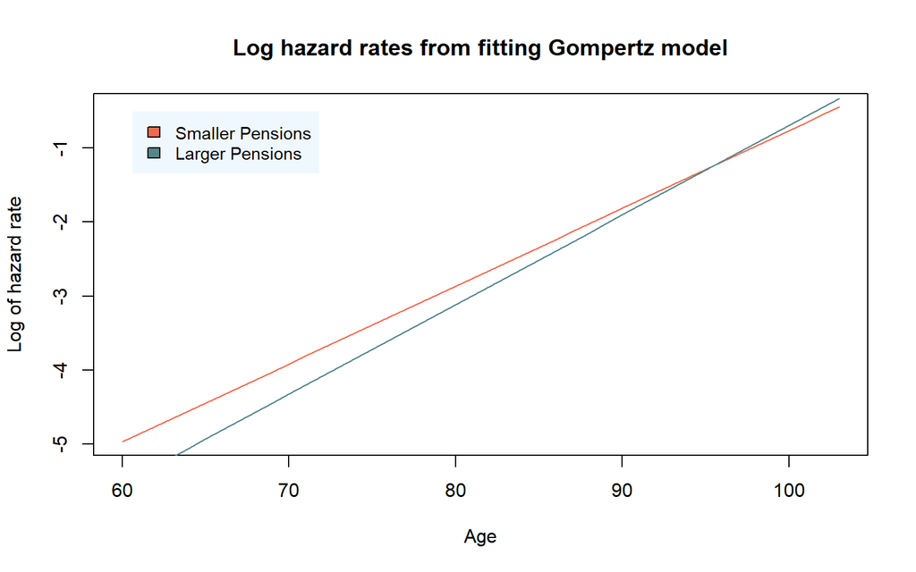

```r
a1=Estimates_LB$estimate[1]
b1=Estimates_LB$estimate[2]
a2=Estimates_HB$estimate[1]
b2=Estimates_HB$estimate[2]


x1=c(min(low_benefit$EntAge):max(low_benefit$EntAge+low_benefit$TObs))
y1=log(Gompertz_hazard(x,a=a1,b=b1))

x2=c(min(high_benefit$EntAge):max(high_benefit$EntAge+high_benefit$TObs))
y2=log(Gompertz_hazard(x,a=a2,b=b2))

plot(x1, y1, type = "l",
     main = "Log hazard rates from fitting Gompertz model",
     xlab="Age", ylab="Log of hazard rate",
     col = "coral2")

lines(x2, y2, col = "cadetblue4")

legend("topleft", c("Smaller Pensions", "Larger Pensions"), fill = c("coral2", "cadetblue4"), bg="aliceblue",box.lty=0, cex=0.9,inset=0.05)
```

Figure 7.12 Log hazard rates from fitting Gompertz model separately to persons with smaller Pensions and larger Pensions.

## 7.4 Proportional Hazards Model

```r
############################7.4 Example: a Proportional Hazards Model
###code 1=gender only ,code 2=Pensions only , code 3(or else)=both
FullNegLogL_Proportional=function(p,data,code){
  a=p[1]
  b=p[2]
  if(code==1){
    zeta_1=p[3]
    zeta_2=0
  }else if(code==2){
    zeta_1=0
    zeta_2=p[3]
  }else {
    zeta_1=p[3]
    zeta_2=p[4]
  }

  x=data$EntAge
  d=data$Status
  t=data$TObs
  z_1=data$Gender
  z_2=data$BH

  sum(((exp(b*t)-1)/b)*exp(a+(b*x)+zeta_1*z_1+zeta_2*z_2))-sum(d*(a+(b*(x+t)+zeta_1*z_1+zeta_2*z_2)))
}

AIC_prop_funct =function(data,p,code){
  k=length(p)
  return((-2)*(-FullNegLogL_Proportional(p,data,code))+2*k)
}

Estimates_gender = nlm( FullNegLogL_Proportional , p = c(-10 , 0.1 , 0.005),data=data,code=1 , typsize = c(-9 , 0.05 ,0.2) , gradtol = 1e-10 , hessian = T)
Identifiability(Estimates_gender)
```

```
## The model is not Identifiable
```

```r
Estimates_gender
```

```
## $minimum
## [1] 20592.59
##
## $estimate
## [1] -11.586546708   0.108333388   0.006462884
##
## $gradient
## [1] 0 0 0
##
## $hessian
##            [,1]       [,2]       [,3]
## [1,]   4960.434   385907.9   2484.142
## [2,] 385907.898 30379429.2 193178.525
## [3,]   2484.142   193178.5   2483.066
##
## $code
## [1] 1
##
## $iterations
## [1] 29
```

```r
knitr::kable(data.frame(AIC =AIC_prop_funct(data,Estimates_gender$estimate,code=1)))
```

| AIC |
| --- |
| 41191.18 |

Figure 7.13 Output from fitting Gompertz model to data with gender as a discrete covariate.

```r
Estimates_benefit = nlm( FullNegLogL_Proportional , p = c(-10.5 , 0.1,-0.2),data=data,code=2 , typsize = c(-10.5 , 0.1,-0.25) , gradtol = 1e-10 , hessian = T)
Identifiability(Estimates_benefit)
```

```
## The model is not Identifiable
```

```r
Estimates_benefit
```

```
## $minimum
## [1] 20561.88
##
## $estimate
## [1] -11.5388401   0.1085182  -0.2755556
##
## $gradient
## [1] 0 0 0
##
## $hessian
##            [,1]        [,2]      [,3]
## [1,]   4961.178   385937.11   947.509
## [2,] 385937.112 30377166.77 73930.275
## [3,]    947.509    73930.27   947.027
##
## $code
## [1] 1
##
## $iterations
## [1] 24
```

```r
knitr::kable(data.frame(AIC =AIC_prop_funct(data,Estimates_benefit$estimate,code=2)))
```

| AIC |
| --- |
| 41129.75 |

Figure 7.17 Output from fitting Gompertz model data with two categories of pension size.

```r
Estimates_gender_benefit = nlm( FullNegLogL_Proportional , p = c(-10.5 , 0.1, 0.008,-0.27),data=data,code=3 , typsize = c(-9 , 0.05,0.1,-10) , gradtol = 1e-10 , hessian = T)
Identifiability(Estimates_gender_benefit)
```

```
## The model is not Identifiable
```

```r
Estimates_gender_benefit
```

```
## $minimum
## [1] 20561.79
##
## $estimate
## [1] -11.54495859   0.10852210   0.01179118  -0.27590281
##
## $gradient
## [1] 5.199382e-08 3.184678e-06 1.818989e-07 8.549250e-08
##
## $hessian
##            [,1]        [,2]        [,3]       [,4]
## [1,]   4960.462   385909.77   2484.1300   947.9000
## [2,] 385909.769 30377224.92 193102.9996 73969.1374
## [3,]   2484.130   193103.00   2482.9933   496.7402
## [4,]    947.900    73969.14    496.7402   947.9474
##
## $code
## [1] 1
##
## $iterations
## [1] 36
```

```r
knitr::kable(data.frame(AIC =AIC_prop_funct(data,Estimates_gender_benefit$estimate,code=3)))
```

| AIC |
| --- |
| 41131.58 |

Figure 7.19 Output from fitting Gompertz model to data with gender and pension size as discrete covariates.

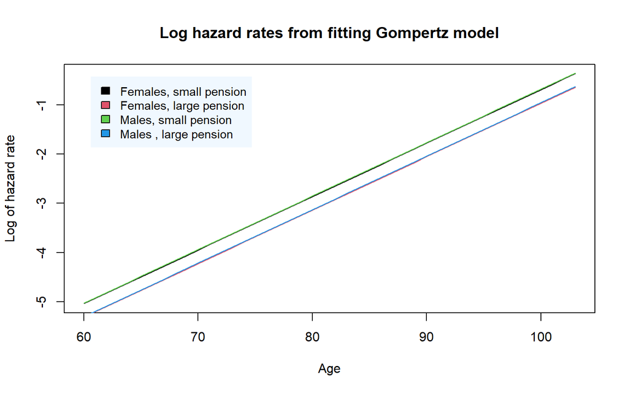

```r
Proportional_Gompertz_hazard=function(p,x,z){
  Gompertz_hazard(x,p[1],p[2])*exp(p[3]*z[1]+p[4]*z[2])
}

p=Estimates_gender_benefit$estimate
x=c(min(high_benefit$EntAge):max(high_benefit$EntAge+high_benefit$TObs))
z=c(0,0)
y=log(Proportional_Gompertz_hazard(p,x,z))

plot(x, y, type = "l",
     main = "Log hazard rates from fitting Gompertz model",
     xlab="Age", ylab="Log of hazard rate",
     col ="cadetblue4")

for(i in 0:1){
  for(j in 0:1){
    z=c(i,j)
    y=log(Proportional_Gompertz_hazard(p,x,z))
    lines(x, y, col =(2*i+j+1))
    legend("topleft", c("Females, small pension", "Females, large pension","Males, small pension","Males , large pension"), fill =c(1:4), bg="aliceblue",box.lty=0, cex=0.9,inset=0.05)

  }
}
```

Figure 7.21 Log hazard rates from fitting Gompertz model to data with gender and pension size as discrete covariates.

# Chapter 8

## 8.3 The Kaplan–Meier Estimator

```r
############################The Kaplan Meier and Fleming Harrington Estimator
Kaplan_Meier=function(data , baseline_age = floor(min(data$Endaage))){

  data$Endaage=data$EntAge+data$TObs
  data <-data[order(data$Endaage),]
  l=c()
  for(i in 1:nrow(data)){

    newdata <- subset(data,((data$EntAge+data$TObs)>=(data$EntAge[i]+data$TObs[i]) & (data$EntAge)<(data$EntAge[i]+data$TObs[i])),select=c(Status,TObs,EntAge))
    l[i]=nrow(newdata)

  }
  data$l=l
  d=c()
  for(i in 1:nrow(data)){

    newdata <- subset(data,((data$EntAge+data$TObs)==(data$EntAge[i]+data$TObs[i]) & data$Status==1))
    d[i]=nrow(newdata)

  }
  data$d=d

  library(dplyr)
  data=distinct(data,data$Endaage,.keep_all=TRUE)

  S=function(d,l){
    1-d/l
  }

  s_base =min(which(floor(data$Endaage) ==  baseline_age))

  S_age = S(data$d[s_base],data$l[s_base])
  for(i in 2:(nrow(data)-s_base+1)){

    S_age[i]=S_age[i-1]*S(data$d[i],data$l[i])

  }


  df=data.frame(data$Endaage[s_base:nrow(data)],data$l[s_base:nrow(data)],data$d[s_base:nrow(data)],S_age)
  df$tosum=df$data.d/((df$data.l-df$data.d)*df$data.l)
  S_hat=c()
  for(i in 1:nrow(df)){
    S_hat[i]=df$S[i]*sqrt(sum(df$tosum[1:i]))
  }
  df$S_hat=S_hat
  df = subset(df, select = -c(tosum) )
  if(baseline_age<data$Endaage[s_base]){df=rbind(c(baseline_age,data$l[1],0,1,0),df)}

  return(df)
}


Kaplan_Meier_table=function(df,baseline_age){
  colnames(df)=c(paste0("xi+ti"),paste0("lxi+ti"),paste0("dxi+ti"),paste0("S_hat_",baseline_age),"s.e")
  return(df)
}



Kaplan_Meier_plot=function(df){
  colnames(df)[1] <- c("data.Endaage")
  n=nrow(df)
  fn <- stepfun(x=df$data.Endaage[-n], y=df$S_age, f=0)
  return(fn)
}
```

```r
baseline_age=60
df=Kaplan_Meier(data,baseline_age)
knitr::kable(Kaplan_Meier_table(head(df,10),baseline_age))
```

| xi+ti | lxi+ti | dxi+ti | S_hat_60 | s.e |
| --- | --- | --- | --- | --- |
| 60.00000 | 7945 | 0 | 1 | 0 |
| 60.00184 | 7945 | 0 | 1 | 0 |
| 60.00274 | 7944 | 0 | 1 | 0 |
| 60.00676 | 8064 | 0 | 1 | 0 |
| 60.00679 | 8063 | 0 | 1 | 0 |
| 60.00972 | 8081 | 0 | 1 | 0 |
| 60.01096 | 8080 | 0 | 1 | 0 |
| 60.01370 | 8098 | 0 | 1 | 0 |
| 60.01915 | 8122 | 0 | 1 | 0 |
| 60.01918 | 8121 | 0 | 1 | 0 |

```r
knitr::kable(Kaplan_Meier_table(tail(df,10),baseline_age))
```

|  | xi+ti | lxi+ti | dxi+ti | S_hat_60 | s.e |
| --- | --- | --- | --- | --- | --- |
| 16751 | 100.3060 | 10 | 1 | 0.0142966 | 0.0038676 |
| 16752 | 100.8016 | 9 | 1 | 0.0127081 | 0.0037499 |
| 16753 | 100.8974 | 8 | 1 | 0.0111196 | 0.0036019 |
| 16754 | 101.3410 | 7 | 1 | 0.0095311 | 0.0034198 |
| 16755 | 101.6860 | 6 | 1 | 0.0079426 | 0.0031975 |
| 16756 | 103.2301 | 5 | 1 | 0.0063541 | 0.0029261 |
| 16757 | 103.3233 | 4 | 0 | 0.0063541 | 0.0029261 |
| 16758 | 103.3397 | 3 | 0 | 0.0063541 | 0.0029261 |
| 16759 | 103.3506 | 2 | 0 | 0.0063541 | 0.0029261 |
| 16760 | 103.3643 | 1 | 0 | 0.0063541 | 0.0029261 |

Table 8.4 Example calculation of Kaplan–Meier estimate $Ŝ (t)$ with approximate standard errors for Combined data.

```r
df_M=Kaplan_Meier(Males)
knitr::kable(Kaplan_Meier_table(head(df_M,10),baseline_age))
```

| xi+ti | lxi+ti | dxi+ti | S_hat_60 | s.e |
| --- | --- | --- | --- | --- |
| 60.00000 | 4011 | 0 | 1.0000000 | 0.0000000 |
| 60.00679 | 4011 | 0 | 1.0000000 | 0.0000000 |
| 60.00972 | 4019 | 0 | 1.0000000 | 0.0000000 |
| 60.01915 | 4038 | 0 | 1.0000000 | 0.0000000 |
| 60.03414 | 4056 | 1 | 0.9997535 | 0.0002465 |
| 60.03923 | 4055 | 0 | 0.9997535 | 0.0002465 |
| 60.04384 | 4058 | 0 | 0.9997535 | 0.0002465 |
| 60.04657 | 4060 | 0 | 0.9997535 | 0.0002465 |
| 60.04811 | 4061 | 0 | 0.9997535 | 0.0002465 |
| 60.05060 | 4062 | 0 | 0.9997535 | 0.0002465 |

```r
knitr::kable(Kaplan_Meier_table(tail(df_M,10),baseline_age))
```

|  | xi+ti | lxi+ti | dxi+ti | S_hat_60 | s.e |
| --- | --- | --- | --- | --- | --- |
| 8757 | 99.29302 | 10 | 1 | 0.0194908 | 0.0057578 |
| 8758 | 99.35329 | 9 | 0 | 0.0194908 | 0.0057578 |
| 8759 | 99.38063 | 8 | 1 | 0.0170544 | 0.0055295 |
| 8760 | 99.39436 | 7 | 0 | 0.0170544 | 0.0055295 |
| 8761 | 99.82143 | 6 | 1 | 0.0142120 | 0.0052883 |
| 8762 | 100.03777 | 5 | 0 | 0.0142120 | 0.0052883 |
| 8763 | 100.27870 | 4 | 0 | 0.0142120 | 0.0052883 |
| 8764 | 100.80161 | 3 | 1 | 0.0094747 | 0.0052336 |
| 8765 | 100.89743 | 2 | 1 | 0.0047373 | 0.0042508 |
| 8766 | 103.32326 | 1 | 0 | 0.0047373 | 0.0042508 |

Example calculation of Kaplan–Meier estimate $Ŝ (t)$ with approximate standard errors for males only.

```r
df_F=Kaplan_Meier(Females)
knitr::kable(Kaplan_Meier_table(head(df_F,10),baseline_age))
```

| xi+ti | lxi+ti | dxi+ti | S_hat_60 | s.e |
| --- | --- | --- | --- | --- |
| 60.00000 | 3987 | 0 | 1.0000000 | 0.0000000 |
| 60.00184 | 3987 | 0 | 1.0000000 | 0.0000000 |
| 60.00274 | 3986 | 0 | 1.0000000 | 0.0000000 |
| 60.00676 | 4053 | 0 | 1.0000000 | 0.0000000 |
| 60.01096 | 4062 | 0 | 1.0000000 | 0.0000000 |
| 60.01370 | 4072 | 0 | 1.0000000 | 0.0000000 |
| 60.01918 | 4084 | 0 | 1.0000000 | 0.0000000 |
| 60.02084 | 4088 | 0 | 1.0000000 | 0.0000000 |
| 60.02466 | 4088 | 0 | 1.0000000 | 0.0000000 |
| 60.02592 | 4087 | 1 | 0.9997553 | 0.0002446 |

```r
knitr::kable(Kaplan_Meier_table(tail(df_F,10),baseline_age))
```

|  | xi+ti | lxi+ti | dxi+ti | S_hat_60 | s.e |
| --- | --- | --- | --- | --- | --- |
| 8825 | 99.60244 | 10 | 0 | 0.0229408 | 0.0063936 |
| 8826 | 99.90905 | 9 | 1 | 0.0203918 | 0.0061705 |
| 8827 | 100.21295 | 8 | 1 | 0.0178428 | 0.0059022 |
| 8828 | 100.30604 | 7 | 1 | 0.0152938 | 0.0055824 |
| 8829 | 101.34097 | 6 | 1 | 0.0127449 | 0.0052015 |
| 8830 | 101.68595 | 5 | 1 | 0.0101959 | 0.0047448 |
| 8831 | 103.23013 | 4 | 1 | 0.0076469 | 0.0041877 |
| 8832 | 103.33969 | 3 | 0 | 0.0076469 | 0.0041877 |
| 8833 | 103.35064 | 2 | 0 | 0.0076469 | 0.0041877 |
| 8834 | 103.36433 | 1 | 0 | 0.0076469 | 0.0041877 |

Example calculation of Kaplan–Meier estimate $Ŝ (t)$ with approximate standard errors for females only.

```r
df_BL=Kaplan_Meier(low_benefit)
knitr::kable(Kaplan_Meier_table(head(df_BL,10),baseline_age))
```

| xi+ti | lxi+ti | dxi+ti | S_hat_60 | s.e |
| --- | --- | --- | --- | --- |
| 60.00000 | 5545 | 0 | 1 | 0 |
| 60.00274 | 5545 | 0 | 1 | 0 |
| 60.00679 | 5606 | 0 | 1 | 0 |
| 60.00972 | 5614 | 0 | 1 | 0 |
| 60.01096 | 5613 | 0 | 1 | 0 |
| 60.01370 | 5622 | 0 | 1 | 0 |
| 60.01915 | 5632 | 0 | 1 | 0 |
| 60.01918 | 5631 | 0 | 1 | 0 |
| 60.02084 | 5635 | 0 | 1 | 0 |
| 60.02466 | 5639 | 0 | 1 | 0 |

```r
knitr::kable(Kaplan_Meier_table(tail(df_BL,10),baseline_age))
```

|  | xi+ti | lxi+ti | dxi+ti | S_hat_60 | s.e |
| --- | --- | --- | --- | --- | --- |
| 12642 | 100.0378 | 10 | 0 | 0.0172135 | 0.0046355 |
| 12643 | 100.2130 | 9 | 1 | 0.0153008 | 0.0044977 |
| 12644 | 100.3060 | 8 | 1 | 0.0133882 | 0.0043231 |
| 12645 | 100.8016 | 7 | 1 | 0.0114756 | 0.0041068 |
| 12646 | 100.8974 | 6 | 1 | 0.0095630 | 0.0038420 |
| 12647 | 101.3410 | 5 | 1 | 0.0076504 | 0.0035176 |
| 12648 | 101.6860 | 4 | 1 | 0.0057378 | 0.0031151 |
| 12649 | 103.3233 | 3 | 0 | 0.0057378 | 0.0031151 |
| 12650 | 103.3506 | 2 | 0 | 0.0057378 | 0.0031151 |
| 12651 | 103.3643 | 1 | 0 | 0.0057378 | 0.0031151 |

Example calculation of Kaplan–Meier estimate $Ŝ (t)$ with approximate standard errors for low benefit only.

```r
df_BH=Kaplan_Meier(high_benefit)
knitr::kable(Kaplan_Meier_table(head(df_BH,10),baseline_age))
```

| xi+ti | lxi+ti | dxi+ti | S_hat_60 | s.e |
| --- | --- | --- | --- | --- |
| 60.00000 | 2400 | 0 | 1.0000000 | 0.0000000 |
| 60.00184 | 2400 | 0 | 1.0000000 | 0.0000000 |
| 60.00676 | 2458 | 0 | 1.0000000 | 0.0000000 |
| 60.02592 | 2496 | 1 | 0.9995994 | 0.0004006 |
| 60.03144 | 2503 | 0 | 0.9995994 | 0.0004006 |
| 60.03288 | 2502 | 0 | 0.9995994 | 0.0004006 |
| 60.03923 | 2506 | 0 | 0.9995994 | 0.0004006 |
| 60.04235 | 2508 | 1 | 0.9992008 | 0.0005649 |
| 60.04395 | 2507 | 0 | 0.9992008 | 0.0005649 |
| 60.04544 | 2508 | 0 | 0.9992008 | 0.0005649 |

```r
knitr::kable(Kaplan_Meier_table(tail(df_BH,10),baseline_age))
```

|  | xi+ti | lxi+ti | dxi+ti | S_hat_60 | s.e |
| --- | --- | --- | --- | --- | --- |
| 4577 | 98.21154 | 10 | 1 | 0.0363990 | 0.0108782 |
| 4578 | 98.25809 | 9 | 1 | 0.0323547 | 0.0103942 |
| 4579 | 98.33201 | 8 | 1 | 0.0283103 | 0.0098504 |
| 4580 | 98.46069 | 7 | 1 | 0.0242660 | 0.0092362 |
| 4581 | 99.35329 | 6 | 0 | 0.0242660 | 0.0092362 |
| 4582 | 99.39436 | 5 | 0 | 0.0242660 | 0.0092362 |
| 4583 | 99.90905 | 4 | 1 | 0.0181995 | 0.0086941 |
| 4584 | 100.27870 | 3 | 0 | 0.0181995 | 0.0086941 |
| 4585 | 103.23013 | 2 | 1 | 0.0090998 | 0.0077653 |
| 4586 | 103.33969 | 1 | 0 | 0.0090998 | 0.0077653 |

Example calculation of Kaplan–Meier estimate $Ŝ (t)$ with approximate standard errors for high benefit only.

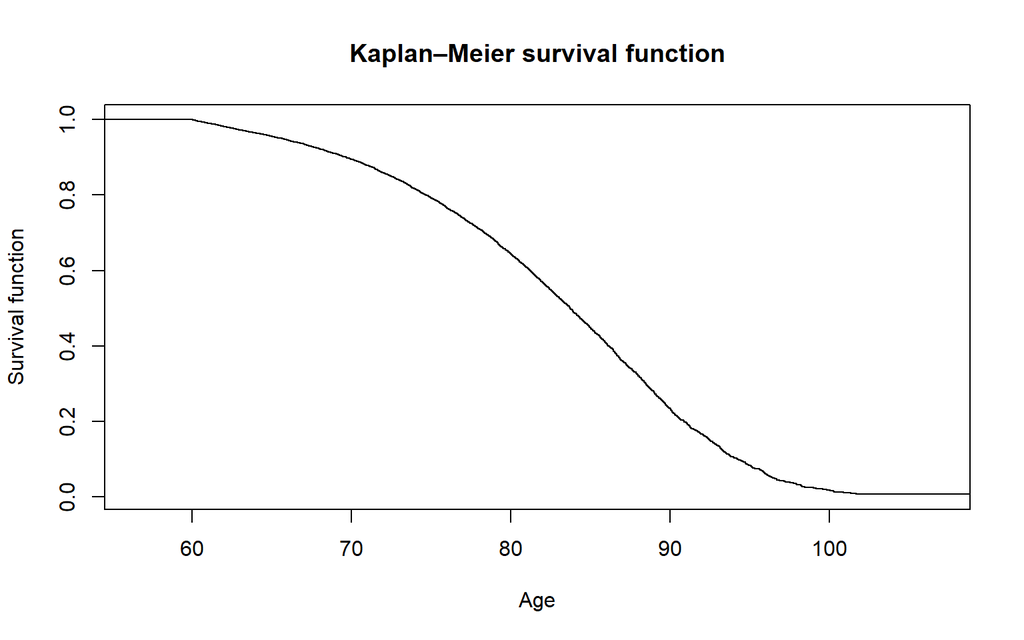

```r
############################Kaplan Meier plots
plot(Kaplan_Meier_plot(df),xlab="Age",ylab="Survival function",main="Kaplan–Meier survival function")
```

Figure 8.3 Kaplan–Meier survival function as per equation (8.3) for Combined data.

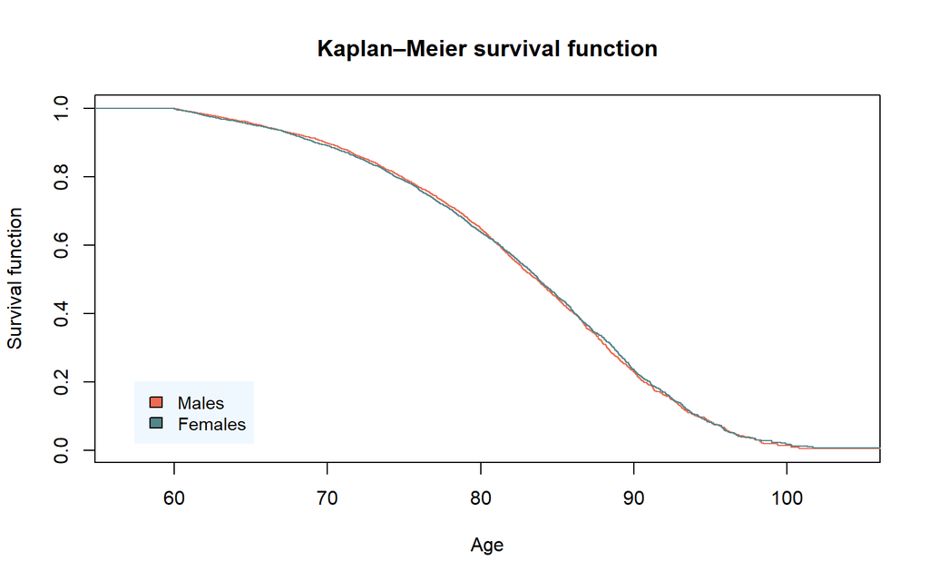

```r
plot(Kaplan_Meier_plot(df_M),xlab="Age",ylab="Survival function",main="Kaplan–Meier survival function",col ="coral2" )

lines(Kaplan_Meier_plot(df_F), col = "cadetblue4")

legend("bottomleft", c("Males", "Females"), fill = c("coral2", "cadetblue4"), bg="aliceblue",box.lty=0, cex=0.9,inset=0.05)
```

Kaplan–Meier survival function as per equation (8.3) for males and females separately.

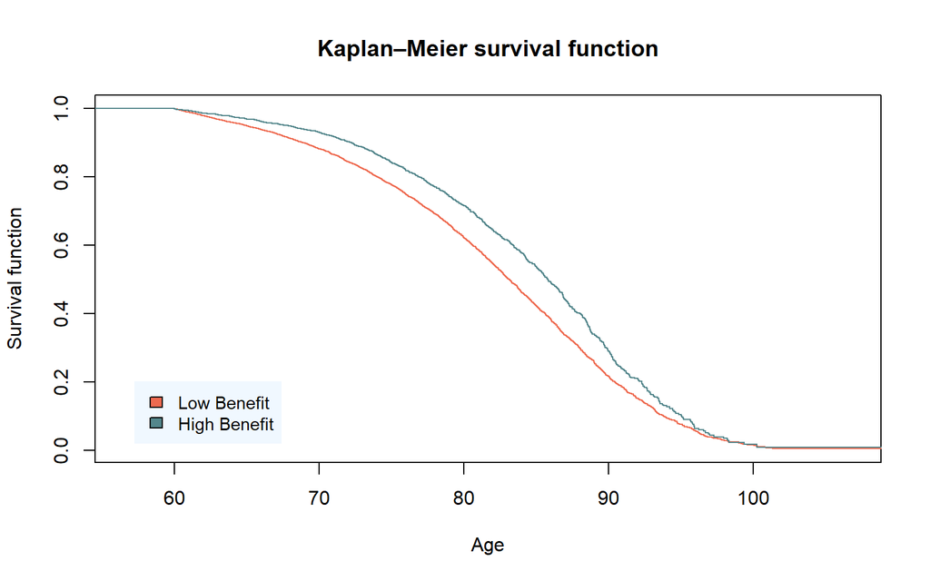

```r
plot(Kaplan_Meier_plot(df_BL),xlab="Age",ylab="Survival function",main="Kaplan–Meier survival function",col ="coral2" )

lines(Kaplan_Meier_plot(df_BH), col = "cadetblue4")

legend("bottomleft", c("Low Benefit", "High Benefit"), fill = c("coral2", "cadetblue4"), bg="aliceblue",box.lty=0, cex=0.9,inset=0.05)
```

Kaplan–Meier survival function as per equation (8.3) for low Benefit and high Benefit separately.

## 8.5 The Fleming–Harrington Estimator

```r
Fleming_Harrington=function(data , baseline_age = floor(min(data$Endaage)) ){

  data$Endaage=data$EntAge+data$TObs
  data <-data[order(data$Endaage),]

  l=c()
  for(i in 1:nrow(data)){
    newdata <- subset(data,((data$EntAge+data$TObs)>=(data$EntAge[i]+data$TObs[i]) & (data$EntAge)<(data$EntAge[i]+data$TObs[i])),select=c(Status,TObs,EntAge))
    l[i]=nrow(newdata)
  }
  data$l=l
  d=c()
  for(i in 1:nrow(data)){

    newdata <- subset(data,((data$EntAge+data$TObs)==(data$EntAge[i]+data$TObs[i]) & data$Status==1))
    d[i]=nrow(newdata)

  }
  data$d=d

  library(dplyr)
  data=distinct(data,data$Endaage,.keep_all=TRUE)

  s_base =min(which(floor(data$Endaage) ==  baseline_age))


  landa=function(d,l){
    d/l
  }

  S_fleming=c()
  for(i in 1:(nrow(data)- s_base + 1)){
    S_fleming[i]=exp(-sum(landa(d,l)[1:i]))
  }

  df=data.frame(data$Endaage[s_base:nrow(data)],data$l[s_base:nrow(data)],data$d[s_base:nrow(data)],S_fleming)
  if(baseline_age<data$Endaage[s_base]){df=rbind(c(baseline_age,data$l[1],0,1),df)}
  return(df)
}
Fleming_Harrington_table=function(df,baseline_age){
  colnames(df)=c(paste0("xi+ti"),paste0("lxi+ti"),paste0("dxi+ti"),paste0("S_hat_",baseline_age))
  return(df)
}

Fleming_Harrington_plot=function(df){
  colnames(df)[1] <- c("data.Endaage")
  n=nrow(df)
  fn <- stepfun(x=df$data.Endaage[-n], y=df$S_fleming, f=0)
  return(fn)
}
```

```r
df_Fleming=Fleming_Harrington(data)
knitr::kable(Fleming_Harrington_table(head(df_Fleming,10),baseline_age))
```

| xi+ti | lxi+ti | dxi+ti | S_hat_60 |
| --- | --- | --- | --- |
| 60.00000 | 7945 | 0 | 1 |
| 60.00184 | 7945 | 0 | 1 |
| 60.00274 | 7944 | 0 | 1 |
| 60.00676 | 8064 | 0 | 1 |
| 60.00679 | 8063 | 0 | 1 |
| 60.00972 | 8081 | 0 | 1 |
| 60.01096 | 8080 | 0 | 1 |
| 60.01370 | 8098 | 0 | 1 |
| 60.01915 | 8122 | 0 | 1 |
| 60.01918 | 8121 | 0 | 1 |

```r
knitr::kable(Fleming_Harrington_table(tail(df_Fleming,10),baseline_age))
```

|  | xi+ti | lxi+ti | dxi+ti | S_hat_60 |
| --- | --- | --- | --- | --- |
| 16751 | 100.3060 | 10 | 1 | 0.3939008 |
| 16752 | 100.8016 | 9 | 1 | 0.3939008 |
| 16753 | 100.8974 | 8 | 1 | 0.3939008 |
| 16754 | 101.3410 | 7 | 1 | 0.3936971 |
| 16755 | 101.6860 | 6 | 1 | 0.3934933 |
| 16756 | 103.2301 | 5 | 1 | 0.3934933 |
| 16757 | 103.3233 | 4 | 0 | 0.3934933 |
| 16758 | 103.3397 | 3 | 0 | 0.3932895 |
| 16759 | 103.3506 | 2 | 0 | 0.3932895 |
| 16760 | 103.3643 | 1 | 0 | 0.3930856 |

Fleming–Harrington estimates for Combined data.

```r
df_M_Fleming=Fleming_Harrington(Males)
knitr::kable(Fleming_Harrington_table(head(df_M_Fleming,10),baseline_age))
```

| xi+ti | lxi+ti | dxi+ti | S_hat_60 |
| --- | --- | --- | --- |
| 60.00000 | 4011 | 0 | 1.0000000 |
| 60.00679 | 4011 | 0 | 1.0000000 |
| 60.00972 | 4019 | 0 | 1.0000000 |
| 60.01915 | 4038 | 0 | 1.0000000 |
| 60.03414 | 4056 | 1 | 0.9997535 |
| 60.03923 | 4055 | 0 | 0.9997535 |
| 60.04384 | 4058 | 0 | 0.9997535 |
| 60.04657 | 4060 | 0 | 0.9997535 |
| 60.04811 | 4061 | 0 | 0.9997535 |
| 60.05060 | 4062 | 0 | 0.9997535 |

```r
knitr::kable(Fleming_Harrington_table(tail(df_M_Fleming,10),baseline_age))
```

|  | xi+ti | lxi+ti | dxi+ti | S_hat_60 |
| --- | --- | --- | --- | --- |
| 8757 | 99.29302 | 10 | 1 | 0.3122720 |
| 8758 | 99.35329 | 9 | 0 | 0.3122720 |
| 8759 | 99.38063 | 8 | 1 | 0.3122720 |
| 8760 | 99.39436 | 7 | 0 | 0.3117537 |
| 8761 | 99.82143 | 6 | 1 | 0.3117537 |
| 8762 | 100.03777 | 5 | 0 | 0.3112345 |
| 8763 | 100.27870 | 4 | 0 | 0.3112345 |
| 8764 | 100.80161 | 3 | 1 | 0.3107145 |
| 8765 | 100.89743 | 2 | 1 | 0.3107145 |
| 8766 | 103.32326 | 1 | 0 | 0.3107145 |

Fleming–Harrington estimates for males only.

```r
df_F_Fleming=Fleming_Harrington(Females)
knitr::kable(Fleming_Harrington_table(head(df_F_Fleming,10),baseline_age))
```

| xi+ti | lxi+ti | dxi+ti | S_hat_60 |
| --- | --- | --- | --- |
| 60.00000 | 3987 | 0 | 1.0000000 |
| 60.00184 | 3987 | 0 | 1.0000000 |
| 60.00274 | 3986 | 0 | 1.0000000 |
| 60.00676 | 4053 | 0 | 1.0000000 |
| 60.01096 | 4062 | 0 | 1.0000000 |
| 60.01370 | 4072 | 0 | 1.0000000 |
| 60.01918 | 4084 | 0 | 1.0000000 |
| 60.02084 | 4088 | 0 | 1.0000000 |
| 60.02466 | 4088 | 0 | 1.0000000 |
| 60.02592 | 4087 | 1 | 0.9997554 |

```r
knitr::kable(Fleming_Harrington_table(tail(df_F_Fleming,10),baseline_age))
```

|  | xi+ti | lxi+ti | dxi+ti | S_hat_60 |
| --- | --- | --- | --- | --- |
| 8825 | 99.60244 | 10 | 0 | 0.3072456 |
| 8826 | 99.90905 | 9 | 1 | 0.3072456 |
| 8827 | 100.21295 | 8 | 1 | 0.3066761 |
| 8828 | 100.30604 | 7 | 1 | 0.3066761 |
| 8829 | 101.34097 | 6 | 1 | 0.3061066 |
| 8830 | 101.68595 | 5 | 1 | 0.3055371 |
| 8831 | 103.23013 | 4 | 1 | 0.3055371 |
| 8832 | 103.33969 | 3 | 0 | 0.3055371 |
| 8833 | 103.35064 | 2 | 0 | 0.3049655 |
| 8834 | 103.36433 | 1 | 0 | 0.3049655 |

Fleming–Harrington estimates for females only.

```r
df_BL_Fleming=Fleming_Harrington(low_benefit)
knitr::kable(Fleming_Harrington_table(head(df_BL_Fleming,10),baseline_age))
```

| xi+ti | lxi+ti | dxi+ti | S_hat_60 |
| --- | --- | --- | --- |
| 60.00000 | 5545 | 0 | 1 |
| 60.00274 | 5545 | 0 | 1 |
| 60.00679 | 5606 | 0 | 1 |
| 60.00972 | 5614 | 0 | 1 |
| 60.01096 | 5613 | 0 | 1 |
| 60.01370 | 5622 | 0 | 1 |
| 60.01915 | 5632 | 0 | 1 |
| 60.01918 | 5631 | 0 | 1 |
| 60.02084 | 5635 | 0 | 1 |
| 60.02466 | 5639 | 0 | 1 |

```r
knitr::kable(Fleming_Harrington_table(tail(df_BL_Fleming,10),baseline_age))
```

|  | xi+ti | lxi+ti | dxi+ti | S_hat_60 |
| --- | --- | --- | --- | --- |
| 12642 | 100.0378 | 10 | 0 | 0.3584310 |
| 12643 | 100.2130 | 9 | 1 | 0.3584310 |
| 12644 | 100.3060 | 8 | 1 | 0.3584310 |
| 12645 | 100.8016 | 7 | 1 | 0.3584310 |
| 12646 | 100.8974 | 6 | 1 | 0.3581590 |
| 12647 | 101.3410 | 5 | 1 | 0.3578869 |
| 12648 | 101.6860 | 4 | 1 | 0.3578869 |
| 12649 | 103.3233 | 3 | 0 | 0.3576147 |
| 12650 | 103.3506 | 2 | 0 | 0.3576147 |
| 12651 | 103.3643 | 1 | 0 | 0.3576147 |

Fleming–Harrington estimates for low benefit only.

```r
df_BH_Fleming=Fleming_Harrington(high_benefit)
knitr::kable(Fleming_Harrington_table(head(df_BH_Fleming,10),baseline_age))
```

| xi+ti | lxi+ti | dxi+ti | S_hat_60 |
| --- | --- | --- | --- |
| 60.00000 | 2400 | 0 | 1.0000000 |
| 60.00184 | 2400 | 0 | 1.0000000 |
| 60.00676 | 2458 | 0 | 1.0000000 |
| 60.02592 | 2496 | 1 | 0.9995994 |
| 60.03144 | 2503 | 0 | 0.9995994 |
| 60.03288 | 2502 | 0 | 0.9995994 |
| 60.03923 | 2506 | 0 | 0.9995994 |
| 60.04235 | 2508 | 1 | 0.9992010 |
| 60.04395 | 2507 | 0 | 0.9992010 |
| 60.04544 | 2508 | 0 | 0.9992010 |

```r
knitr::kable(Fleming_Harrington_table(tail(df_BH_Fleming,10),baseline_age))
```

|  | xi+ti | lxi+ti | dxi+ti | S_hat_60 |
| --- | --- | --- | --- | --- |
| 4577 | 98.21154 | 10 | 1 | 0.2806058 |
| 4578 | 98.25809 | 9 | 1 | 0.2788790 |
| 4579 | 98.33201 | 8 | 1 | 0.2788790 |
| 4580 | 98.46069 | 7 | 1 | 0.2788790 |
| 4581 | 99.35329 | 6 | 0 | 0.2788790 |
| 4582 | 99.39436 | 5 | 0 | 0.2771196 |
| 4583 | 99.90905 | 4 | 1 | 0.2771196 |
| 4584 | 100.27870 | 3 | 0 | 0.2753488 |
| 4585 | 103.23013 | 2 | 1 | 0.2735781 |
| 4586 | 103.33969 | 1 | 0 | 0.2718074 |

Fleming–Harrington estimates for high benefit only.

**Fleming Harrington plots**

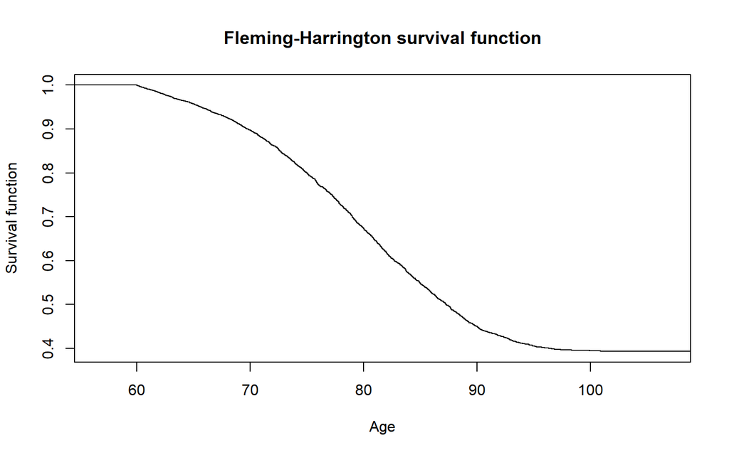

```r
############################Fleming Harrington plots
plot(Fleming_Harrington_plot(df_Fleming),xlab="Age",ylab="Survival function",main="Fleming-Harrington survival function")
```

Fleming Harrington survival function for combined data.

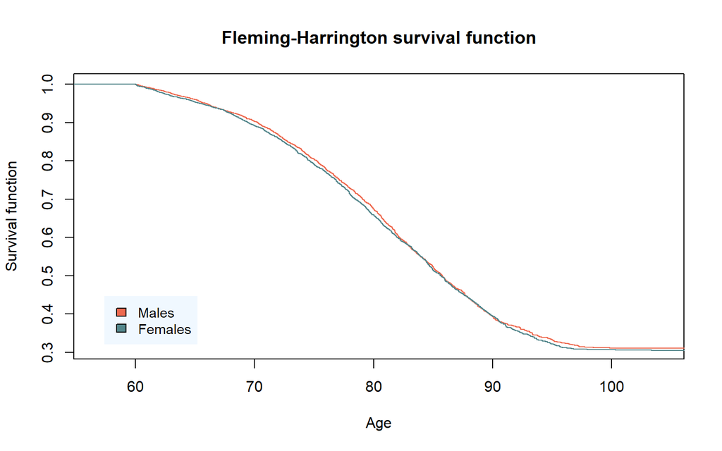

```r
plot(Fleming_Harrington_plot(df_M_Fleming),xlab="Age",ylab="Survival function",main="Fleming-Harrington survival function",col ="coral2" )

lines(Fleming_Harrington_plot(df_F_Fleming), col = "cadetblue4")

legend("bottomleft", c("Males", "Females"), fill = c("coral2", "cadetblue4"), bg="aliceblue",box.lty=0, cex=0.9,inset=0.05)
```

Fleming Harrington survival function for males and females separately.

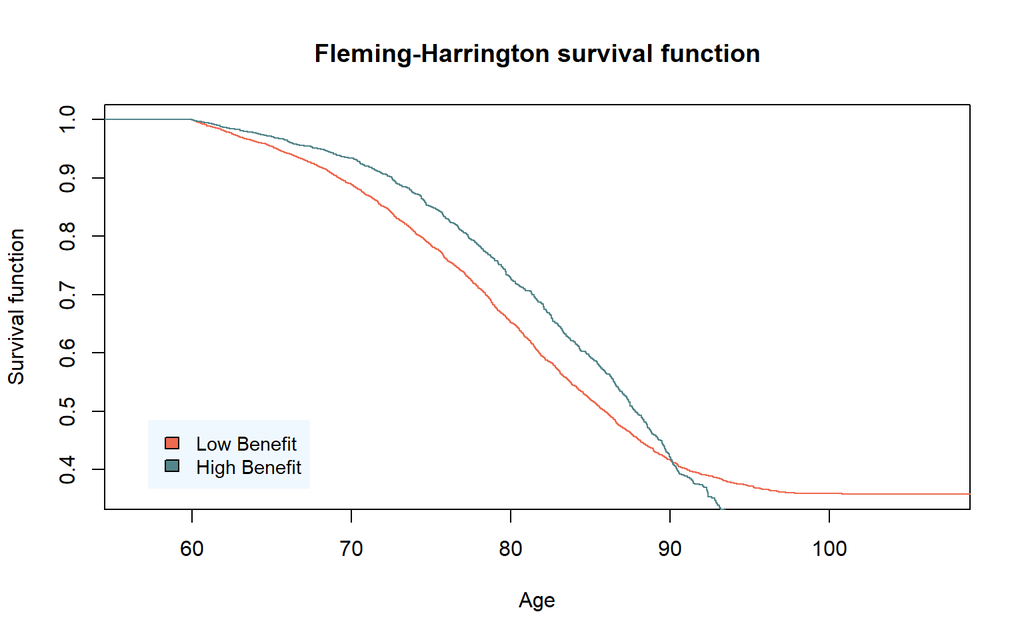

```r
plot(Fleming_Harrington_plot(df_BL_Fleming),xlab="Age",ylab="Survival function",main="Fleming-Harrington survival function",col ="coral2" )

lines(Fleming_Harrington_plot(df_BH_Fleming), col = "cadetblue4")

legend("bottomleft", c("Low Benefit", "High Benefit"), fill = c("coral2", "cadetblue4"), bg="aliceblue",box.lty=0, cex=0.9,inset=0.05)
```

Fleming Harrington survival function for low Benefit and high Benefit separately.